# examples_0528

To find the total cost of Quintin's shopping trip, multiply each quantity by its corresponding unit price and then add up all those products.

$$(3\cdot1.62)~+~(0\cdot0.79)~+~(2\cdot7.26)~+~(5\cdot7.97)$$
$$4.86~+~0~+~14.52~+~39.85$$
$$59.23$$

So, the total cost of Quintin shopping at Overpriced Options is $59.23.

In standard math notation, the matrix multiplication would be shown as:

$$\begin{bmatrix}
3 & 0 & 2 & 5\\
2 & 1 & 0 & 3\\
0 & 1 & 2 & 1
\end{bmatrix} \cdot \begin{bmatrix}
1.5 & 1.56 & 1.67 & 1.62 & 1.66\\
1.08 & 0.7 & 0.92 & 0.79 & 1\\
4.6 & 5.86 & 5.9 & 7.26 & 5.13\\
6.04 & 6.31 & 7.14 & 7.97 & 7.86
\end{bmatrix} ~=~ \begin{bmatrix}
43.9 & 47.95 & 52.51 & 59.23 & 54.54\\
22.2 & 22.75 & 25.68 & 27.94 & 27.9\\
16.32 & 18.73 & 19.86 & 23.28 & 19.12
\end{bmatrix}$$

Three people are buying fruit, and there are five grocery stores. Each person has a shopping list dictating how many pounds of each fruit to buy. Each store has different unit costs of fruit.

In order to consider the **total** cost for each person at each store, we can use [matrix multiplication](https://en.wikipedia.org/wiki/Matrix_multiplication). In order to help visualize matrix multiplication, the shopping lists are shown as a matrix on the bottom-left, the unit prices as a matrix on top-right, and the resulting matrix of totals in the bottom-right.

A peculiarity of matrix multiplication requires the **columns** of the first matrix to "match" the **rows** of the second matrix. In this case, notice the various fruits correspond to columns in the first matrix (bottom-left) and rows in the second matrix (top-right). This visualization is an attempt to make this seem more natural.

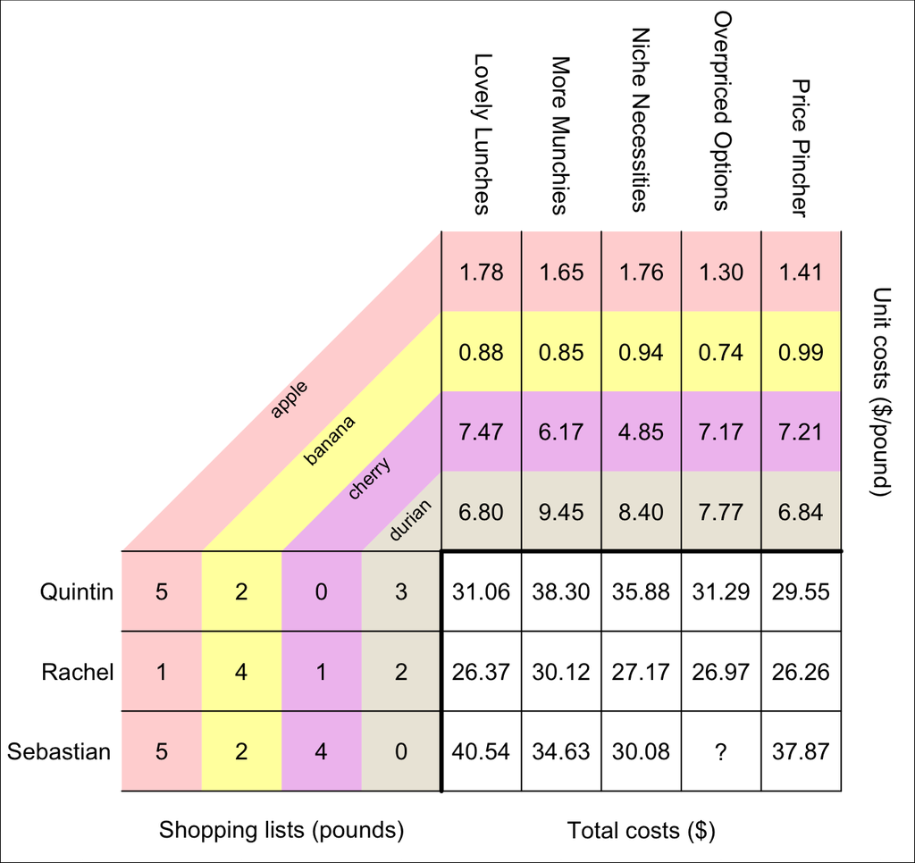

What is the total cost of Sebastian shopping at Overpriced Options?

Sebastian wishes to buy 5 lb of apple, 2 lb of banana, 4 lb of cherry, and 0 lb of durian. At Overpriced Options, the unit price of apple is $1.30/lb, the unit price of banana is $0.74/lb, the unit price of cherry is $7.17/lb, and the unit price of durian is $7.77/lb.

To find the total cost of Sebastian's shopping trip, multiply each quantity by its corresponding unit price and then add up all those products.

$$(5\cdot1.3)~+~(2\cdot0.74)~+~(4\cdot7.17)~+~(0\cdot7.77)$$
$$6.5~+~1.48~+~28.68~+~0$$
$$36.66$$

So, the total cost of Sebastian shopping at Overpriced Options is $36.66.

In standard math notation, the matrix multiplication would be shown as:

$$\begin{bmatrix}
5 & 2 & 0 & 3\\
1 & 4 & 1 & 2\\
5 & 2 & 4 & 0
\end{bmatrix} \cdot \begin{bmatrix}
1.78 & 1.65 & 1.76 & 1.3 & 1.41\\
0.88 & 0.85 & 0.94 & 0.74 & 0.99\\
7.47 & 6.17 & 4.85 & 7.17 & 7.21\\
6.8 & 9.45 & 8.4 & 7.77 & 6.84
\end{bmatrix} ~=~ \begin{bmatrix}
31.06 & 38.3 & 35.88 & 31.29 & 29.55\\
26.37 & 30.12 & 27.17 & 26.97 & 26.26\\
40.54 & 34.63 & 30.08 & 36.66 & 37.87
\end{bmatrix}$$

Three people are buying fruit, and there are five grocery stores. Each person has a shopping list dictating how many pounds of each fruit to buy. Each store has different unit costs of fruit.

In order to consider the **total** cost for each person at each store, we can use [matrix multiplication](https://en.wikipedia.org/wiki/Matrix_multiplication). In order to help visualize matrix multiplication, the shopping lists are shown as a matrix on the bottom-left, the unit prices as a matrix on top-right, and the resulting matrix of totals in the bottom-right.

A peculiarity of matrix multiplication requires the **columns** of the first matrix to "match" the **rows** of the second matrix. In this case, notice the various fruits correspond to columns in the first matrix (bottom-left) and rows in the second matrix (top-right). This visualization is an attempt to make this seem more natural.

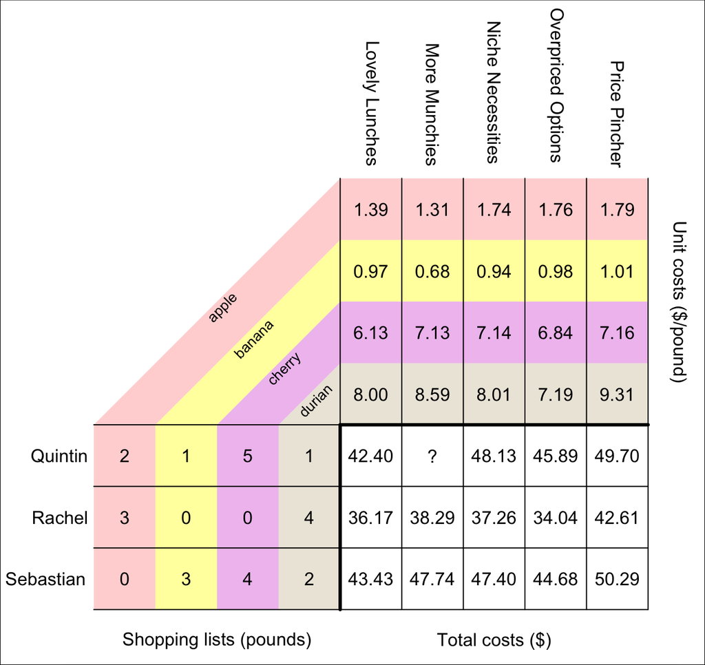

What is the total cost of Quintin shopping at More Munchies?

Quintin wishes to buy 2 lb of apple, 1 lb of banana, 5 lb of cherry, and 1 lb of durian. At More Munchies, the unit price of apple is $1.31/lb, the unit price of banana is $0.68/lb, the unit price of cherry is $7.13/lb, and the unit price of durian is $8.59/lb.

To find the total cost of Quintin's shopping trip, multiply each quantity by its corresponding unit price and then add up all those products.

$$(2\cdot1.31)~+~(1\cdot0.68)~+~(5\cdot7.13)~+~(1\cdot8.59)$$
$$2.62~+~0.68~+~35.65~+~8.59$$
$$47.54$$

So, the total cost of Quintin shopping at More Munchies is $47.54.

In standard math notation, the matrix multiplication would be shown as:

$$\begin{bmatrix}
2 & 1 & 5 & 1\\
3 & 0 & 0 & 4\\
0 & 3 & 4 & 2
\end{bmatrix} \cdot \begin{bmatrix}
1.39 & 1.31 & 1.74 & 1.76 & 1.79\\
0.97 & 0.68 & 0.94 & 0.98 & 1.01\\
6.13 & 7.13 & 7.14 & 6.84 & 7.16\\
8 & 8.59 & 8.01 & 7.19 & 9.31
\end{bmatrix} ~=~ \begin{bmatrix}
42.4 & 47.54 & 48.13 & 45.89 & 49.7\\
36.17 & 38.29 & 37.26 & 34.04 & 42.61\\
43.43 & 47.74 & 47.4 & 44.68 & 50.29
\end{bmatrix}$$

Three people are buying fruit, and there are five grocery stores. Each person has a shopping list dictating how many pounds of each fruit to buy. Each store has different unit costs of fruit.

In order to consider the **total** cost for each person at each store, we can use [matrix multiplication](https://en.wikipedia.org/wiki/Matrix_multiplication). In order to help visualize matrix multiplication, the shopping lists are shown as a matrix on the bottom-left, the unit prices as a matrix on top-right, and the resulting (unfilled) matrix of totals in the bottom-right.

A peculiarity of matrix multiplication requires the **columns** of the first matrix to "match" the **rows** of the second matrix. In this case, notice the various fruits correspond to columns in the first matrix (bottom-left) and rows in the second matrix (top-right). This visualization is an attempt to make this seem more natural.

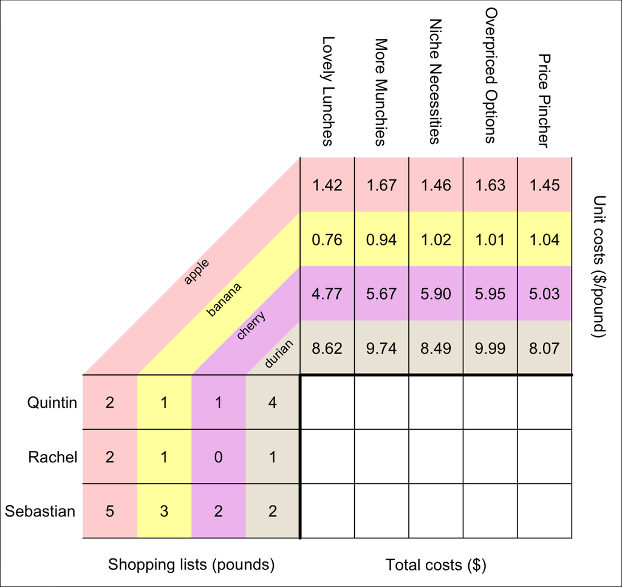

What is the total cost of Sebastian shopping at Lovely Lunches?

Sebastian wishes to buy 5 lb of apple, 3 lb of banana, 2 lb of cherry, and 2 lb of durian. At Lovely Lunches, the unit price of apple is $1.42/lb, the unit price of banana is $0.76/lb, the unit price of cherry is $4.77/lb, and the unit price of durian is $8.62/lb.

To find the total cost of Sebastian's shopping trip, multiply each quantity by its corresponding unit price and then add up all those products.

$$(5\cdot1.42)~+~(3\cdot0.76)~+~(2\cdot4.77)~+~(2\cdot8.62)$$
$$7.1~+~2.28~+~9.54~+~17.24$$
$$36.16$$

So, the total cost of Sebastian shopping at Lovely Lunches is $36.16.

In standard math notation, the matrix multiplication would be shown as:

$$\begin{bmatrix}
2 & 1 & 1 & 4\\
2 & 1 & 0 & 1\\
5 & 3 & 2 & 2
\end{bmatrix} \cdot \begin{bmatrix}
1.42 & 1.67 & 1.46 & 1.63 & 1.45\\
0.76 & 0.94 & 1.02 & 1.01 & 1.04\\
4.77 & 5.67 & 5.9 & 5.95 & 5.03\\
8.62 & 9.74 & 8.49 & 9.99 & 8.07
\end{bmatrix} ~=~ \begin{bmatrix}
42.85 & 48.91 & 43.8 & 50.18 & 41.25\\
12.22 & 14.02 & 12.43 & 14.26 & 12.01\\
36.16 & 41.99 & 39.14 & 43.06 & 36.57
\end{bmatrix}$$

Three people are buying fruit, and there are five grocery stores. Each person has a shopping list dictating how many pounds of each fruit to buy. Each store has different unit costs of fruit.

In order to consider the **total** cost for each person at each store, we can use [matrix multiplication](https://en.wikipedia.org/wiki/Matrix_multiplication). In order to help visualize matrix multiplication, the shopping lists are shown as a matrix on the bottom-left, the unit prices as a matrix on top-right, and the resulting (unfilled) matrix of totals in the bottom-right.

A peculiarity of matrix multiplication requires the **columns** of the first matrix to "match" the **rows** of the second matrix. In this case, notice the various fruits correspond to columns in the first matrix (bottom-left) and rows in the second matrix (top-right). This visualization is an attempt to make this seem more natural.

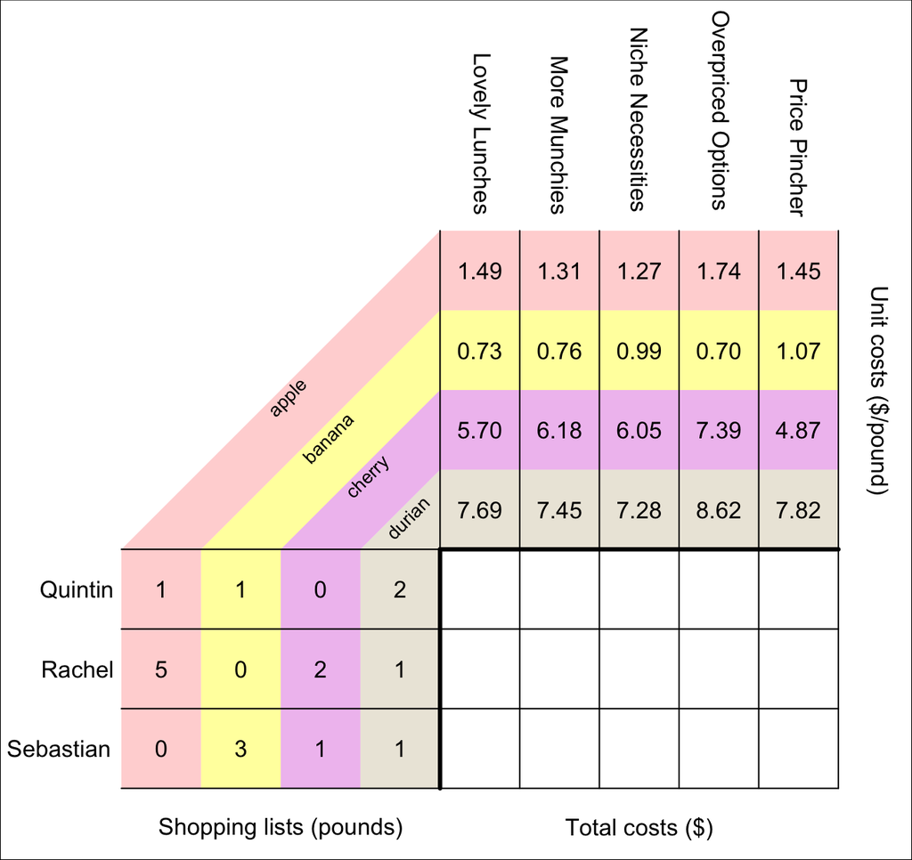

What is the total cost of Quintin shopping at More Munchies?

Quintin wishes to buy 1 lb of apple, 1 lb of banana, 0 lb of cherry, and 2 lb of durian. At More Munchies, the unit price of apple is $1.31/lb, the unit price of banana is $0.76/lb, the unit price of cherry is $6.18/lb, and the unit price of durian is $7.45/lb.

To find the total cost of Quintin's shopping trip, multiply each quantity by its corresponding unit price and then add up all those products.

$$(1\cdot1.31)~+~(1\cdot0.76)~+~(0\cdot6.18)~+~(2\cdot7.45)$$
$$1.31~+~0.76~+~0~+~14.9$$
$$16.97$$

So, the total cost of Quintin shopping at More Munchies is $16.97.

In standard math notation, the matrix multiplication would be shown as:

$$\begin{bmatrix}
1 & 1 & 0 & 2\\
5 & 0 & 2 & 1\\
0 & 3 & 1 & 1
\end{bmatrix} \cdot \begin{bmatrix}
1.49 & 1.31 & 1.27 & 1.74 & 1.45\\
0.73 & 0.76 & 0.99 & 0.7 & 1.07\\
5.7 & 6.18 & 6.05 & 7.39 & 4.87\\
7.69 & 7.45 & 7.28 & 8.62 & 7.82
\end{bmatrix} ~=~ \begin{bmatrix}
17.6 & 16.97 & 16.82 & 19.68 & 18.16\\
26.54 & 26.36 & 25.73 & 32.1 & 24.81\\
15.58 & 15.91 & 16.3 & 18.11 & 15.9
\end{bmatrix}$$

Three people are buying fruit, and there are five grocery stores. Each person has a shopping list dictating how many pounds of each fruit to buy. Each store has different unit costs of fruit.

In order to consider the **total** cost for each person at each store, we can use [matrix multiplication](https://en.wikipedia.org/wiki/Matrix_multiplication). In order to help visualize matrix multiplication, the shopping lists are shown as a matrix on the bottom-left, the unit prices as a matrix on top-right, and the resulting (unfilled) matrix of totals in the bottom-right.

A peculiarity of matrix multiplication requires the **columns** of the first matrix to "match" the **rows** of the second matrix. In this case, notice the various fruits correspond to columns in the first matrix (bottom-left) and rows in the second matrix (top-right). This visualization is an attempt to make this seem more natural.

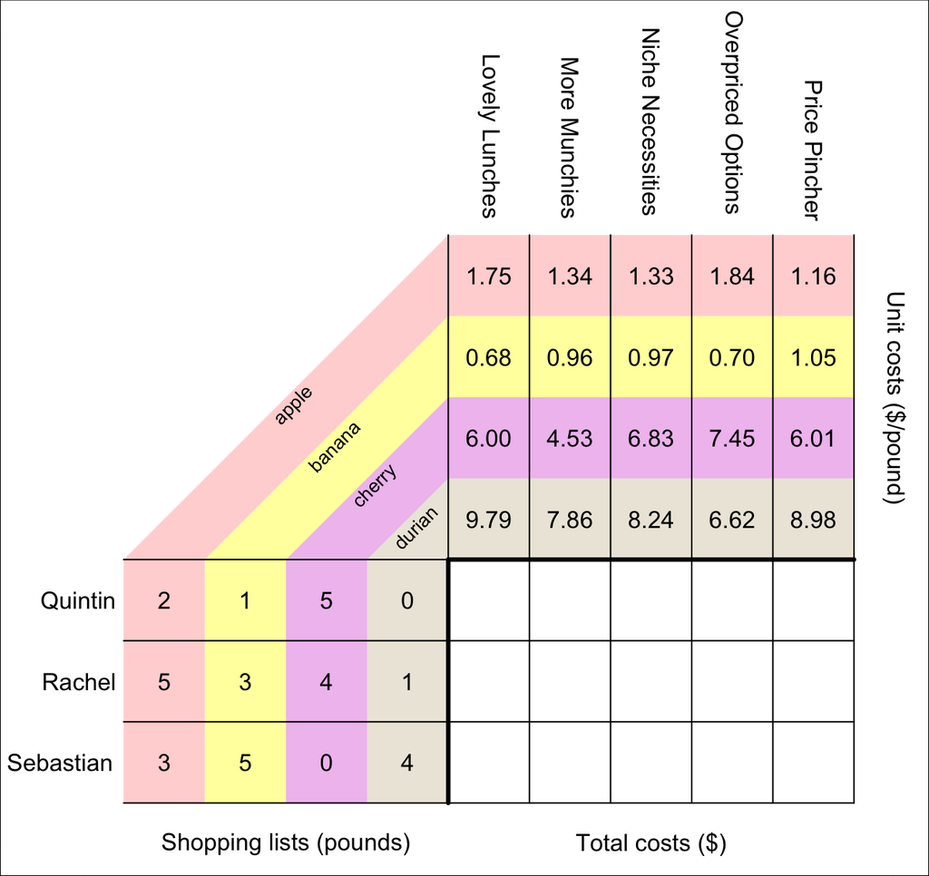

What is the total cost of Sebastian shopping at More Munchies?

Sebastian wishes to buy 3 lb of apple, 5 lb of banana, 0 lb of cherry, and 4 lb of durian. At More Munchies, the unit price of apple is $1.34/lb, the unit price of banana is $0.96/lb, the unit price of cherry is $4.53/lb, and the unit price of durian is $7.86/lb.

To find the total cost of Sebastian's shopping trip, multiply each quantity by its corresponding unit price and then add up all those products.

$$(3\cdot1.34)~+~(5\cdot0.96)~+~(0\cdot4.53)~+~(4\cdot7.86)$$
$$4.02~+~4.8~+~0~+~31.44$$
$$40.26$$

So, the total cost of Sebastian shopping at More Munchies is $40.26.

In standard math notation, the matrix multiplication would be shown as:

$$\begin{bmatrix}
2 & 1 & 5 & 0\\
5 & 3 & 4 & 1\\
3 & 5 & 0 & 4
\end{bmatrix} \cdot \begin{bmatrix}
1.75 & 1.34 & 1.33 & 1.84 & 1.16\\
0.68 & 0.96 & 0.97 & 0.7 & 1.05\\
6 & 4.53 & 6.83 & 7.45 & 6.01\\
9.79 & 7.86 & 8.24 & 6.62 & 8.98
\end{bmatrix} ~=~ \begin{bmatrix}
34.18 & 26.29 & 37.78 & 41.63 & 33.42\\
44.58 & 35.56 & 45.12 & 47.72 & 41.97\\
47.81 & 40.26 & 41.8 & 35.5 & 44.65
\end{bmatrix}$$

Three people are buying fruit, and there are five grocery stores. Each person has a shopping list dictating how many pounds of each fruit to buy. Each store has different unit costs of fruit.

In order to consider the **total** cost for each person at each store, we can use [matrix multiplication](https://en.wikipedia.org/wiki/Matrix_multiplication). In order to help visualize matrix multiplication, the shopping lists are shown as a matrix on the bottom-left, the unit prices as a matrix on top-right, and the resulting (unfilled) matrix of totals in the bottom-right.

A peculiarity of matrix multiplication requires the **columns** of the first matrix to "match" the **rows** of the second matrix. In this case, notice the various fruits correspond to columns in the first matrix (bottom-left) and rows in the second matrix (top-right). This visualization is an attempt to make this seem more natural.

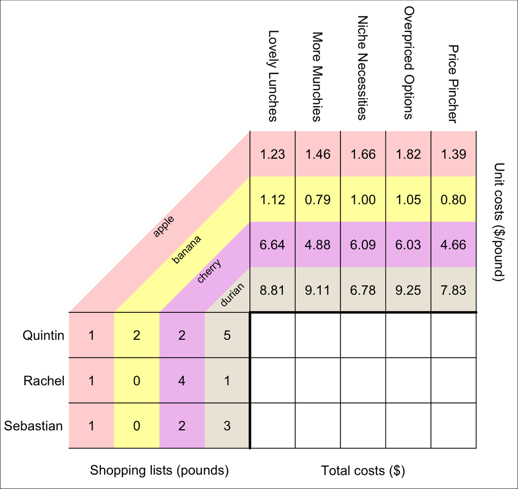

What is the total cost of Quintin shopping at More Munchies?

Quintin wishes to buy 1 lb of apple, 2 lb of banana, 2 lb of cherry, and 5 lb of durian. At More Munchies, the unit price of apple is $1.46/lb, the unit price of banana is $0.79/lb, the unit price of cherry is $4.88/lb, and the unit price of durian is $9.11/lb.

To find the total cost of Quintin's shopping trip, multiply each quantity by its corresponding unit price and then add up all those products.

$$(1\cdot1.46)~+~(2\cdot0.79)~+~(2\cdot4.88)~+~(5\cdot9.11)$$
$$1.46~+~1.58~+~9.76~+~45.55$$
$$58.35$$

So, the total cost of Quintin shopping at More Munchies is $58.35.

In standard math notation, the matrix multiplication would be shown as:

$$\begin{bmatrix}
1 & 2 & 2 & 5\\
1 & 0 & 4 & 1\\
1 & 0 & 2 & 3
\end{bmatrix} \cdot \begin{bmatrix}
1.23 & 1.46 & 1.66 & 1.82 & 1.39\\
1.12 & 0.79 & 1 & 1.05 & 0.8\\
6.64 & 4.88 & 6.09 & 6.03 & 4.66\\
8.81 & 9.11 & 6.78 & 9.25 & 7.83
\end{bmatrix} ~=~ \begin{bmatrix}
60.8 & 58.35 & 49.74 & 62.23 & 51.46\\
36.6 & 30.09 & 32.8 & 35.19 & 27.86\\
40.94 & 38.55 & 34.18 & 41.63 & 34.2
\end{bmatrix}$$

Three people are buying fruit, and there are five grocery stores. Each person has a shopping list dictating how many pounds of each fruit to buy. Each store has different unit costs of fruit.

In order to consider the **total** cost for each person at each store, we can use [matrix multiplication](https://en.wikipedia.org/wiki/Matrix_multiplication). In order to help visualize matrix multiplication, the shopping lists are shown as a matrix on the bottom-left, the unit prices as a matrix on top-right, and the resulting (unfilled) matrix of totals in the bottom-right.

A peculiarity of matrix multiplication requires the **columns** of the first matrix to "match" the **rows** of the second matrix. In this case, notice the various fruits correspond to columns in the first matrix (bottom-left) and rows in the second matrix (top-right). This visualization is an attempt to make this seem more natural.

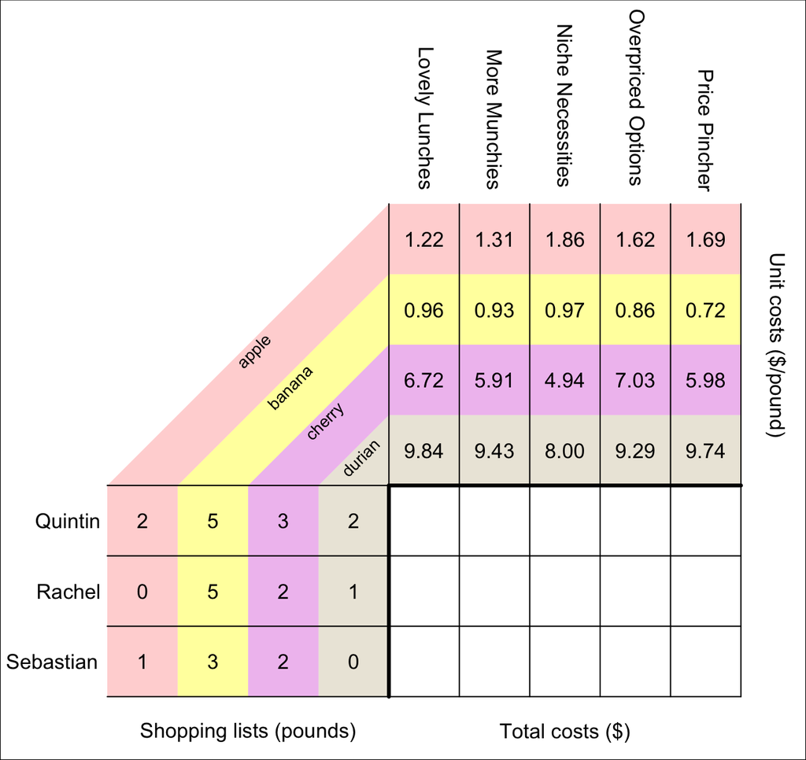

What is the total cost of Rachel shopping at Lovely Lunches?

Rachel wishes to buy 0 lb of apple, 5 lb of banana, 2 lb of cherry, and 1 lb of durian. At Lovely Lunches, the unit price of apple is $1.22/lb, the unit price of banana is $0.96/lb, the unit price of cherry is $6.72/lb, and the unit price of durian is $9.84/lb.

To find the total cost of Rachel's shopping trip, multiply each quantity by its corresponding unit price and then add up all those products.

$$(0\cdot1.22)~+~(5\cdot0.96)~+~(2\cdot6.72)~+~(1\cdot9.84)$$
$$0~+~4.8~+~13.44~+~9.84$$
$$28.08$$

So, the total cost of Rachel shopping at Lovely Lunches is $28.08.

In standard math notation, the matrix multiplication would be shown as:

$$\begin{bmatrix}
2 & 5 & 3 & 2\\
0 & 5 & 2 & 1\\
1 & 3 & 2 & 0
\end{bmatrix} \cdot \begin{bmatrix}
1.22 & 1.31 & 1.86 & 1.62 & 1.69\\
0.96 & 0.93 & 0.97 & 0.86 & 0.72\\
6.72 & 5.91 & 4.94 & 7.03 & 5.98\\
9.84 & 9.43 & 8 & 9.29 & 9.74
\end{bmatrix} ~=~ \begin{bmatrix}
47.08 & 43.86 & 39.39 & 47.21 & 44.4\\
28.08 & 25.9 & 22.73 & 27.65 & 25.3\\
17.54 & 15.92 & 14.65 & 18.26 & 15.81
\end{bmatrix}$$

Three people are buying fruit, and there are five grocery stores. Each person has a shopping list dictating how many pounds of each fruit to buy. Each store has different unit costs of fruit.

In order to consider the **total** cost for each person at each store, we can use [matrix multiplication](https://en.wikipedia.org/wiki/Matrix_multiplication). In order to help visualize matrix multiplication, the shopping lists are shown as a matrix on the bottom-left, the unit prices as a matrix on top-right, and the resulting (unfilled) matrix of totals in the bottom-right.

A peculiarity of matrix multiplication requires the **columns** of the first matrix to "match" the **rows** of the second matrix. In this case, notice the various fruits correspond to columns in the first matrix (bottom-left) and rows in the second matrix (top-right). This visualization is an attempt to make this seem more natural.

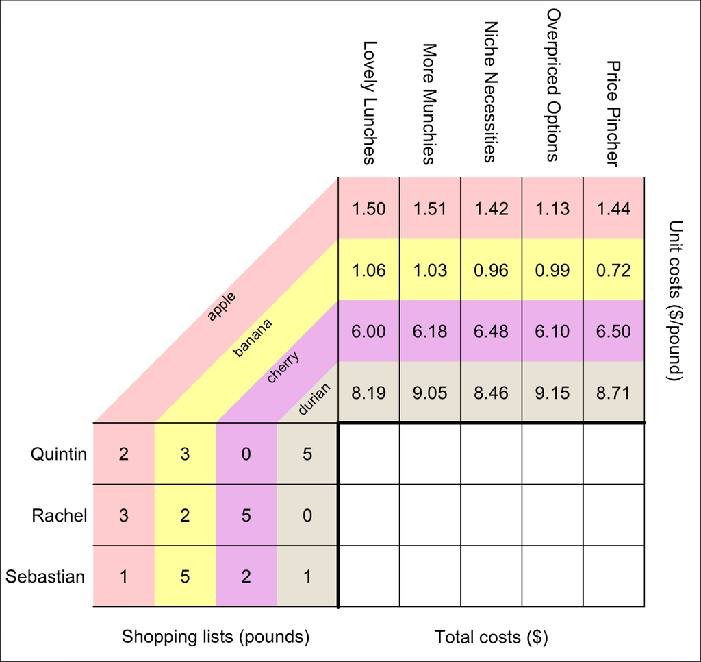

What is the total cost of Sebastian shopping at More Munchies?

Sebastian wishes to buy 1 lb of apple, 5 lb of banana, 2 lb of cherry, and 1 lb of durian. At More Munchies, the unit price of apple is $1.51/lb, the unit price of banana is $1.03/lb, the unit price of cherry is $6.18/lb, and the unit price of durian is $9.05/lb.

To find the total cost of Sebastian's shopping trip, multiply each quantity by its corresponding unit price and then add up all those products.

$$(1\cdot1.51)~+~(5\cdot1.03)~+~(2\cdot6.18)~+~(1\cdot9.05)$$
$$1.51~+~5.15~+~12.36~+~9.05$$
$$28.07$$

So, the total cost of Sebastian shopping at More Munchies is $28.07.

In standard math notation, the matrix multiplication would be shown as:

$$\begin{bmatrix}
2 & 3 & 0 & 5\\
3 & 2 & 5 & 0\\
1 & 5 & 2 & 1
\end{bmatrix} \cdot \begin{bmatrix}
1.5 & 1.51 & 1.42 & 1.13 & 1.44\\
1.06 & 1.03 & 0.96 & 0.99 & 0.72\\
6 & 6.18 & 6.48 & 6.1 & 6.5\\
8.19 & 9.05 & 8.46 & 9.15 & 8.71
\end{bmatrix} ~=~ \begin{bmatrix}
47.13 & 51.36 & 48.02 & 50.98 & 48.59\\
36.62 & 37.49 & 38.58 & 35.87 & 38.26\\
26.99 & 28.07 & 27.64 & 27.43 & 26.75
\end{bmatrix}$$

Three people are buying fruit, and there are five grocery stores. Each person has a shopping list dictating how many pounds of each fruit to buy. Each store has different unit costs of fruit.

In order to consider the **total** cost for each person at each store, we can use [matrix multiplication](https://en.wikipedia.org/wiki/Matrix_multiplication). In order to help visualize matrix multiplication, the shopping lists are shown as a matrix on the bottom-left, the unit prices as a matrix on top-right, and the resulting (unfilled) matrix of totals in the bottom-right.

A peculiarity of matrix multiplication requires the **columns** of the first matrix to "match" the **rows** of the second matrix. In this case, notice the various fruits correspond to columns in the first matrix (bottom-left) and rows in the second matrix (top-right). This visualization is an attempt to make this seem more natural.

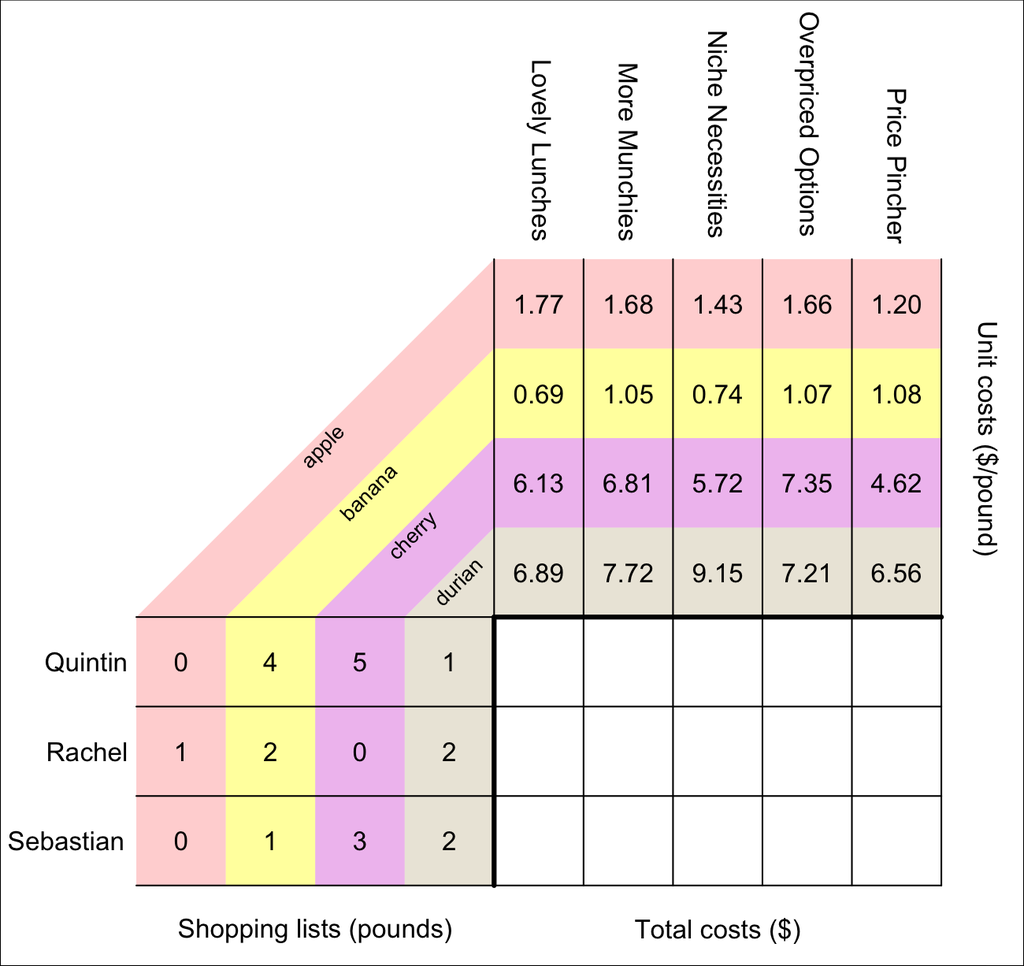

What is the total cost of Quintin shopping at More Munchies?

Quintin wishes to buy 0 lb of apple, 4 lb of banana, 5 lb of cherry, and 1 lb of durian. At More Munchies, the unit price of apple is $1.68/lb, the unit price of banana is $1.05/lb, the unit price of cherry is $6.81/lb, and the unit price of durian is $7.72/lb.

To find the total cost of Quintin's shopping trip, multiply each quantity by its corresponding unit price and then add up all those products.

$$(0\cdot1.68)~+~(4\cdot1.05)~+~(5\cdot6.81)~+~(1\cdot7.72)$$
$$0~+~4.2~+~34.05~+~7.72$$
$$45.97$$

So, the total cost of Quintin shopping at More Munchies is $45.97.

In standard math notation, the matrix multiplication would be shown as:

$$\begin{bmatrix}
0 & 4 & 5 & 1\\
1 & 2 & 0 & 2\\
0 & 1 & 3 & 2
\end{bmatrix} \cdot \begin{bmatrix}
1.77 & 1.68 & 1.43 & 1.66 & 1.2\\
0.69 & 1.05 & 0.74 & 1.07 & 1.08\\
6.13 & 6.81 & 5.72 & 7.35 & 4.62\\
6.89 & 7.72 & 9.15 & 7.21 & 6.56
\end{bmatrix} ~=~ \begin{bmatrix}
40.3 & 45.97 & 40.71 & 48.24 & 33.98\\
16.93 & 19.22 & 21.21 & 18.22 & 16.48\\
32.86 & 36.92 & 36.2 & 37.54 & 28.06
\end{bmatrix}$$

Three people are buying fruit, and there are five grocery stores. Each person has a shopping list dictating how many pounds of each fruit to buy. Each store has different unit costs of fruit.

In order to consider the **total** cost for each person at each store, we can use [matrix multiplication](https://en.wikipedia.org/wiki/Matrix_multiplication). In order to help visualize matrix multiplication, the shopping lists are shown as a matrix on the bottom-left, the unit prices as a matrix on top-right, and the resulting (unfilled) matrix of totals in the bottom-right.

A peculiarity of matrix multiplication requires the **columns** of the first matrix to "match" the **rows** of the second matrix. In this case, notice the various fruits correspond to columns in the first matrix (bottom-left) and rows in the second matrix (top-right). This visualization is an attempt to make this seem more natural.

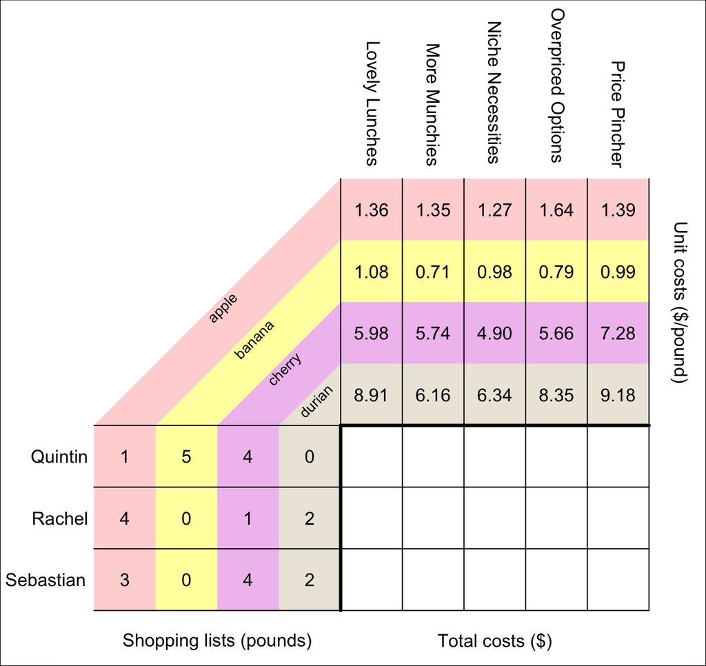

What is the total cost of Quintin shopping at Lovely Lunches?

Quintin wishes to buy 1 lb of apple, 5 lb of banana, 4 lb of cherry, and 0 lb of durian. At Lovely Lunches, the unit price of apple is $1.36/lb, the unit price of banana is $1.08/lb, the unit price of cherry is $5.98/lb, and the unit price of durian is $8.91/lb.

To find the total cost of Quintin's shopping trip, multiply each quantity by its corresponding unit price and then add up all those products.

$$(1\cdot1.36)~+~(5\cdot1.08)~+~(4\cdot5.98)~+~(0\cdot8.91)$$
$$1.36~+~5.4~+~23.92~+~0$$
$$30.68$$

So, the total cost of Quintin shopping at Lovely Lunches is $30.68.

In standard math notation, the matrix multiplication would be shown as:

$$\begin{bmatrix}
1 & 5 & 4 & 0\\
4 & 0 & 1 & 2\\
3 & 0 & 4 & 2
\end{bmatrix} \cdot \begin{bmatrix}
1.36 & 1.35 & 1.27 & 1.64 & 1.39\\
1.08 & 0.71 & 0.98 & 0.79 & 0.99\\
5.98 & 5.74 & 4.9 & 5.66 & 7.28\\
8.91 & 6.16 & 6.34 & 8.35 & 9.18
\end{bmatrix} ~=~ \begin{bmatrix}
30.68 & 27.86 & 25.77 & 28.23 & 35.46\\
29.24 & 23.46 & 22.66 & 28.92 & 31.2\\
45.82 & 39.33 & 36.09 & 44.26 & 51.65
\end{bmatrix}$$

Three people are buying fruit, and there are five grocery stores. Each person has a shopping list dictating how many pounds of each fruit to buy. Each store has different unit costs of fruit.

In order to consider the **total** cost for each person at each store, we can use [matrix multiplication](https://en.wikipedia.org/wiki/Matrix_multiplication). In order to help visualize matrix multiplication, the shopping lists are shown as a matrix on the bottom-left, the unit prices as a matrix on top-right, and the resulting (unfilled) matrix of totals in the bottom-right.

A peculiarity of matrix multiplication requires the **columns** of the first matrix to "match" the **rows** of the second matrix. In this case, notice the various fruits correspond to columns in the first matrix (bottom-left) and rows in the second matrix (top-right). This visualization is an attempt to make this seem more natural.

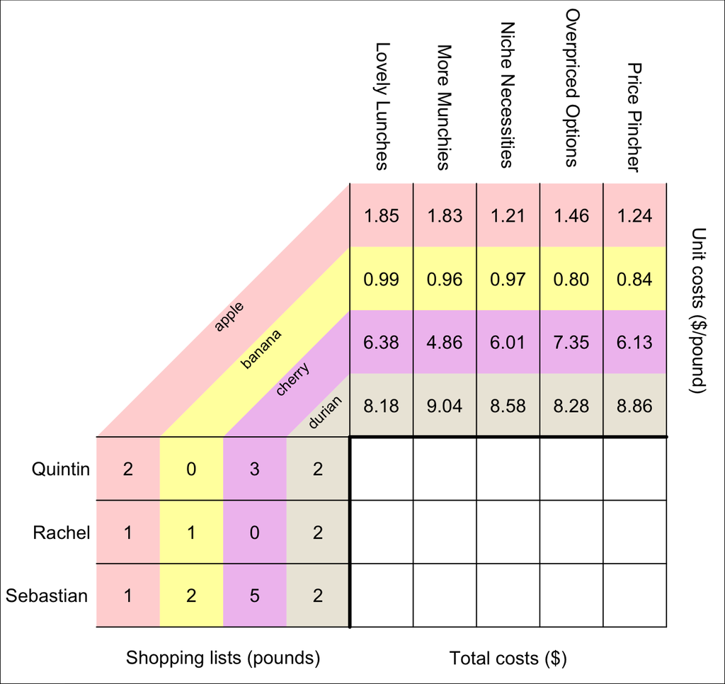

What is the total cost of Sebastian shopping at More Munchies?

Sebastian wishes to buy 1 lb of apple, 2 lb of banana, 5 lb of cherry, and 2 lb of durian. At More Munchies, the unit price of apple is $1.83/lb, the unit price of banana is $0.96/lb, the unit price of cherry is $4.86/lb, and the unit price of durian is $9.04/lb.

To find the total cost of Sebastian's shopping trip, multiply each quantity by its corresponding unit price and then add up all those products.

$$(1\cdot1.83)~+~(2\cdot0.96)~+~(5\cdot4.86)~+~(2\cdot9.04)$$
$$1.83~+~1.92~+~24.3~+~18.08$$
$$46.13$$

So, the total cost of Sebastian shopping at More Munchies is $46.13.

In standard math notation, the matrix multiplication would be shown as:

$$\begin{bmatrix}
2 & 0 & 3 & 2\\
1 & 1 & 0 & 2\\
1 & 2 & 5 & 2
\end{bmatrix} \cdot \begin{bmatrix}
1.85 & 1.83 & 1.21 & 1.46 & 1.24\\
0.99 & 0.96 & 0.97 & 0.8 & 0.84\\
6.38 & 4.86 & 6.01 & 7.35 & 6.13\\
8.18 & 9.04 & 8.58 & 8.28 & 8.86
\end{bmatrix} ~=~ \begin{bmatrix}
39.2 & 36.32 & 37.61 & 41.53 & 38.59\\
19.2 & 20.87 & 19.34 & 18.82 & 19.8\\
52.09 & 46.13 & 50.36 & 56.37 & 51.29
\end{bmatrix}$$

Three people are buying fruit, and there are five grocery stores. Each person has a shopping list dictating how many pounds of each fruit to buy. Each store has different unit costs of fruit.

In order to consider the **total** cost for each person at each store, we can use [matrix multiplication](https://en.wikipedia.org/wiki/Matrix_multiplication). In order to help visualize matrix multiplication, the shopping lists are shown as a matrix on the bottom-left, the unit prices as a matrix on top-right, and the resulting (unfilled) matrix of totals in the bottom-right.

A peculiarity of matrix multiplication requires the **columns** of the first matrix to "match" the **rows** of the second matrix. In this case, notice the various fruits correspond to columns in the first matrix (bottom-left) and rows in the second matrix (top-right). This visualization is an attempt to make this seem more natural.

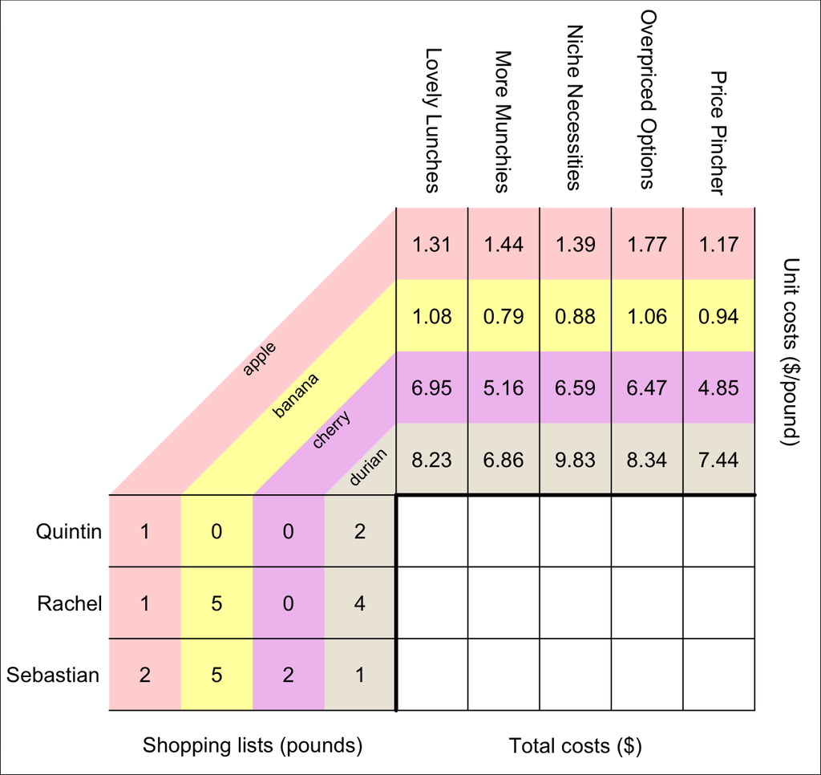

What is the total cost of Quintin shopping at More Munchies?

Quintin wishes to buy 1 lb of apple, 0 lb of banana, 0 lb of cherry, and 2 lb of durian. At More Munchies, the unit price of apple is $1.44/lb, the unit price of banana is $0.79/lb, the unit price of cherry is $5.16/lb, and the unit price of durian is $6.86/lb.

To find the total cost of Quintin's shopping trip, multiply each quantity by its corresponding unit price and then add up all those products.

$$(1\cdot1.44)~+~(0\cdot0.79)~+~(0\cdot5.16)~+~(2\cdot6.86)$$
$$1.44~+~0~+~0~+~13.72$$
$$15.16$$

So, the total cost of Quintin shopping at More Munchies is $15.16.

In standard math notation, the matrix multiplication would be shown as:

$$\begin{bmatrix}
1 & 0 & 0 & 2\\
1 & 5 & 0 & 4\\
2 & 5 & 2 & 1
\end{bmatrix} \cdot \begin{bmatrix}
1.31 & 1.44 & 1.39 & 1.77 & 1.17\\
1.08 & 0.79 & 0.88 & 1.06 & 0.94\\
6.95 & 5.16 & 6.59 & 6.47 & 4.85\\
8.23 & 6.86 & 9.83 & 8.34 & 7.44
\end{bmatrix} ~=~ \begin{bmatrix}
17.77 & 15.16 & 21.05 & 18.45 & 16.05\\
39.63 & 32.83 & 45.11 & 40.43 & 35.63\\
30.15 & 24.01 & 30.19 & 30.12 & 24.18
\end{bmatrix}$$

Three people are buying fruit, and there are five grocery stores. Each person has a shopping list dictating how many pounds of each fruit to buy. Each store has different unit costs of fruit.

In order to consider the **total** cost for each person at each store, we can use [matrix multiplication](https://en.wikipedia.org/wiki/Matrix_multiplication). In order to help visualize matrix multiplication, the shopping lists are shown as a matrix on the bottom-left, the unit prices as a matrix on top-right, and the resulting (unfilled) matrix of totals in the bottom-right.

A peculiarity of matrix multiplication requires the **columns** of the first matrix to "match" the **rows** of the second matrix. In this case, notice the various fruits correspond to columns in the first matrix (bottom-left) and rows in the second matrix (top-right). This visualization is an attempt to make this seem more natural.

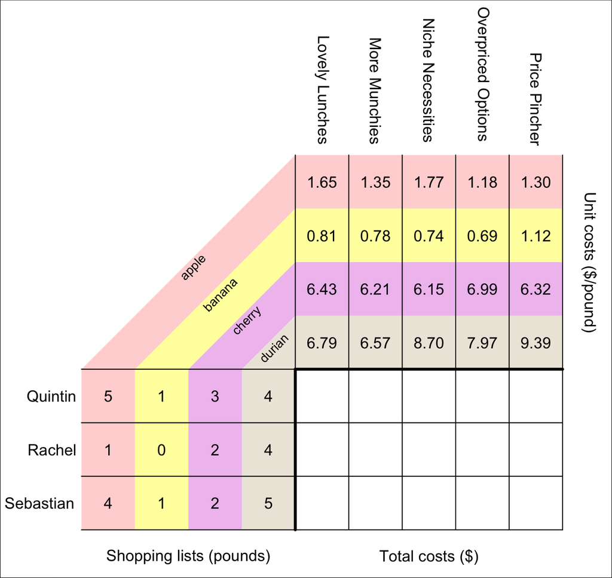

What is the total cost of Sebastian shopping at Lovely Lunches?

Sebastian wishes to buy 4 lb of apple, 1 lb of banana, 2 lb of cherry, and 5 lb of durian. At Lovely Lunches, the unit price of apple is $1.65/lb, the unit price of banana is $0.81/lb, the unit price of cherry is $6.43/lb, and the unit price of durian is $6.79/lb.

To find the total cost of Sebastian's shopping trip, multiply each quantity by its corresponding unit price and then add up all those products.

$$(4\cdot1.65)~+~(1\cdot0.81)~+~(2\cdot6.43)~+~(5\cdot6.79)$$
$$6.6~+~0.81~+~12.86~+~33.95$$
$$54.22$$

So, the total cost of Sebastian shopping at Lovely Lunches is $54.22.

In standard math notation, the matrix multiplication would be shown as:

$$\begin{bmatrix}
5 & 1 & 3 & 4\\
1 & 0 & 2 & 4\\
4 & 1 & 2 & 5
\end{bmatrix} \cdot \begin{bmatrix}
1.65 & 1.35 & 1.77 & 1.18 & 1.3\\
0.81 & 0.78 & 0.74 & 0.69 & 1.12\\
6.43 & 6.21 & 6.15 & 6.99 & 6.32\\
6.79 & 6.57 & 8.7 & 7.97 & 9.39
\end{bmatrix} ~=~ \begin{bmatrix}
55.51 & 52.44 & 62.84 & 59.44 & 64.14\\
41.67 & 40.05 & 48.87 & 47.04 & 51.5\\
54.22 & 51.45 & 63.62 & 59.24 & 65.91
\end{bmatrix}$$

Three people are buying fruit, and there are five grocery stores. Each person has a shopping list dictating how many pounds of each fruit to buy. Each store has different unit costs of fruit.

In order to consider the **total** cost for each person at each store, we can use [matrix multiplication](https://en.wikipedia.org/wiki/Matrix_multiplication). In order to help visualize matrix multiplication, the shopping lists are shown as a matrix on the bottom-left, the unit prices as a matrix on top-right, and the resulting (unfilled) matrix of totals in the bottom-right.

A peculiarity of matrix multiplication requires the **columns** of the first matrix to "match" the **rows** of the second matrix. In this case, notice the various fruits correspond to columns in the first matrix (bottom-left) and rows in the second matrix (top-right). This visualization is an attempt to make this seem more natural.

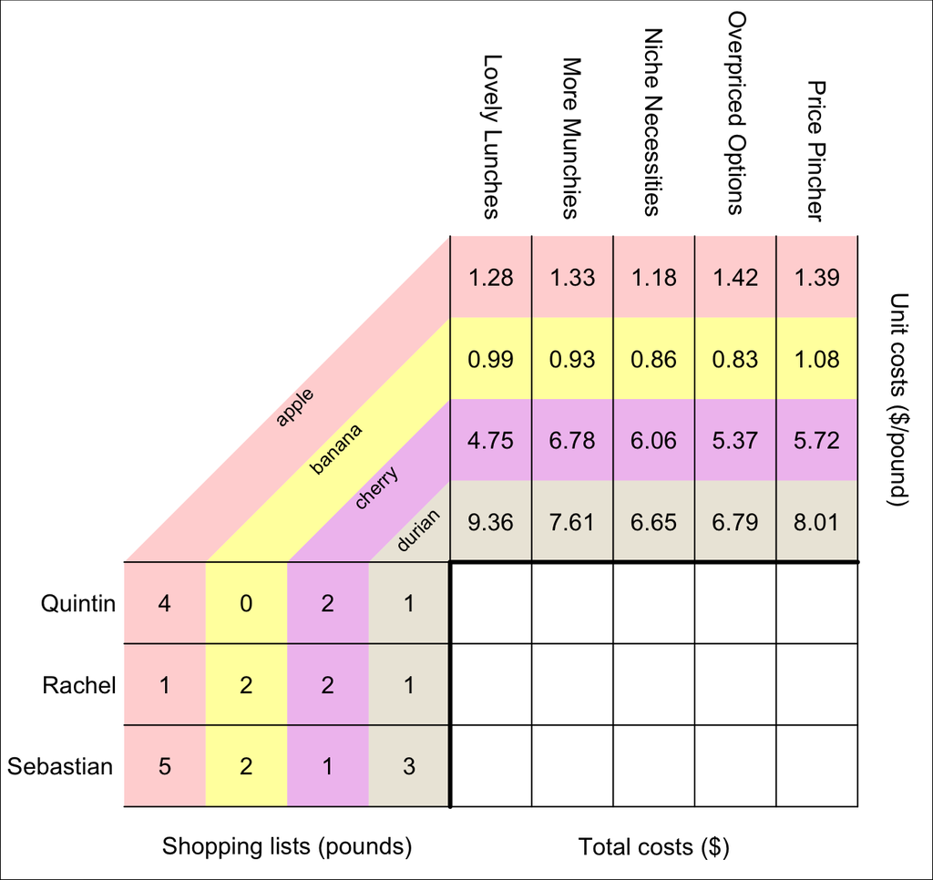

What is the total cost of Rachel shopping at Lovely Lunches?

Rachel wishes to buy 1 lb of apple, 2 lb of banana, 2 lb of cherry, and 1 lb of durian. At Lovely Lunches, the unit price of apple is $1.28/lb, the unit price of banana is $0.99/lb, the unit price of cherry is $4.75/lb, and the unit price of durian is $9.36/lb.

To find the total cost of Rachel's shopping trip, multiply each quantity by its corresponding unit price and then add up all those products.

$$(1\cdot1.28)~+~(2\cdot0.99)~+~(2\cdot4.75)~+~(1\cdot9.36)$$
$$1.28~+~1.98~+~9.5~+~9.36$$
$$22.12$$

So, the total cost of Rachel shopping at Lovely Lunches is $22.12.

In standard math notation, the matrix multiplication would be shown as:

$$\begin{bmatrix}
4 & 0 & 2 & 1\\
1 & 2 & 2 & 1\\
5 & 2 & 1 & 3
\end{bmatrix} \cdot \begin{bmatrix}
1.28 & 1.33 & 1.18 & 1.42 & 1.39\\
0.99 & 0.93 & 0.86 & 0.83 & 1.08\\
4.75 & 6.78 & 6.06 & 5.37 & 5.72\\
9.36 & 7.61 & 6.65 & 6.79 & 8.01
\end{bmatrix} ~=~ \begin{bmatrix}
23.98 & 26.49 & 23.49 & 23.21 & 25.01\\
22.12 & 24.36 & 21.67 & 20.61 & 23\\
41.21 & 38.12 & 33.63 & 34.5 & 38.86
\end{bmatrix}$$

Three people are buying fruit, and there are five grocery stores. Each person has a shopping list dictating how many pounds of each fruit to buy. Each store has different unit costs of fruit.

In order to consider the **total** cost for each person at each store, we can use [matrix multiplication](https://en.wikipedia.org/wiki/Matrix_multiplication). In order to help visualize matrix multiplication, the shopping lists are shown as a matrix on the bottom-left, the unit prices as a matrix on top-right, and the resulting (unfilled) matrix of totals in the bottom-right.

A peculiarity of matrix multiplication requires the **columns** of the first matrix to "match" the **rows** of the second matrix. In this case, notice the various fruits correspond to columns in the first matrix (bottom-left) and rows in the second matrix (top-right). This visualization is an attempt to make this seem more natural.

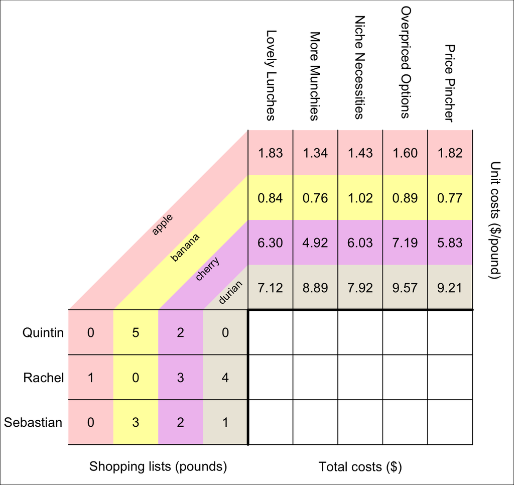

What is the total cost of Sebastian shopping at More Munchies?

Sebastian wishes to buy 0 lb of apple, 3 lb of banana, 2 lb of cherry, and 1 lb of durian. At More Munchies, the unit price of apple is $1.34/lb, the unit price of banana is $0.76/lb, the unit price of cherry is $4.92/lb, and the unit price of durian is $8.89/lb.

To find the total cost of Sebastian's shopping trip, multiply each quantity by its corresponding unit price and then add up all those products.

$$(0\cdot1.34)~+~(3\cdot0.76)~+~(2\cdot4.92)~+~(1\cdot8.89)$$
$$0~+~2.28~+~9.84~+~8.89$$
$$21.01$$

So, the total cost of Sebastian shopping at More Munchies is $21.01.

In standard math notation, the matrix multiplication would be shown as:

$$\begin{bmatrix}
0 & 5 & 2 & 0\\
1 & 0 & 3 & 4\\
0 & 3 & 2 & 1
\end{bmatrix} \cdot \begin{bmatrix}
1.83 & 1.34 & 1.43 & 1.6 & 1.82\\
0.84 & 0.76 & 1.02 & 0.89 & 0.77\\
6.3 & 4.92 & 6.03 & 7.19 & 5.83\\
7.12 & 8.89 & 7.92 & 9.57 & 9.21
\end{bmatrix} ~=~ \begin{bmatrix}
16.8 & 13.64 & 17.16 & 18.83 & 15.51\\
49.21 & 51.66 & 51.2 & 61.45 & 56.15\\
22.24 & 21.01 & 23.04 & 26.62 & 23.18
\end{bmatrix}$$

Three people are buying fruit, and there are five grocery stores. Each person has a shopping list dictating how many pounds of each fruit to buy. Each store has different unit costs of fruit.

In order to consider the **total** cost for each person at each store, we can use [matrix multiplication](https://en.wikipedia.org/wiki/Matrix_multiplication). In order to help visualize matrix multiplication, the shopping lists are shown as a matrix on the bottom-left, the unit prices as a matrix on top-right, and the resulting (unfilled) matrix of totals in the bottom-right.

A peculiarity of matrix multiplication requires the **columns** of the first matrix to "match" the **rows** of the second matrix. In this case, notice the various fruits correspond to columns in the first matrix (bottom-left) and rows in the second matrix (top-right). This visualization is an attempt to make this seem more natural.

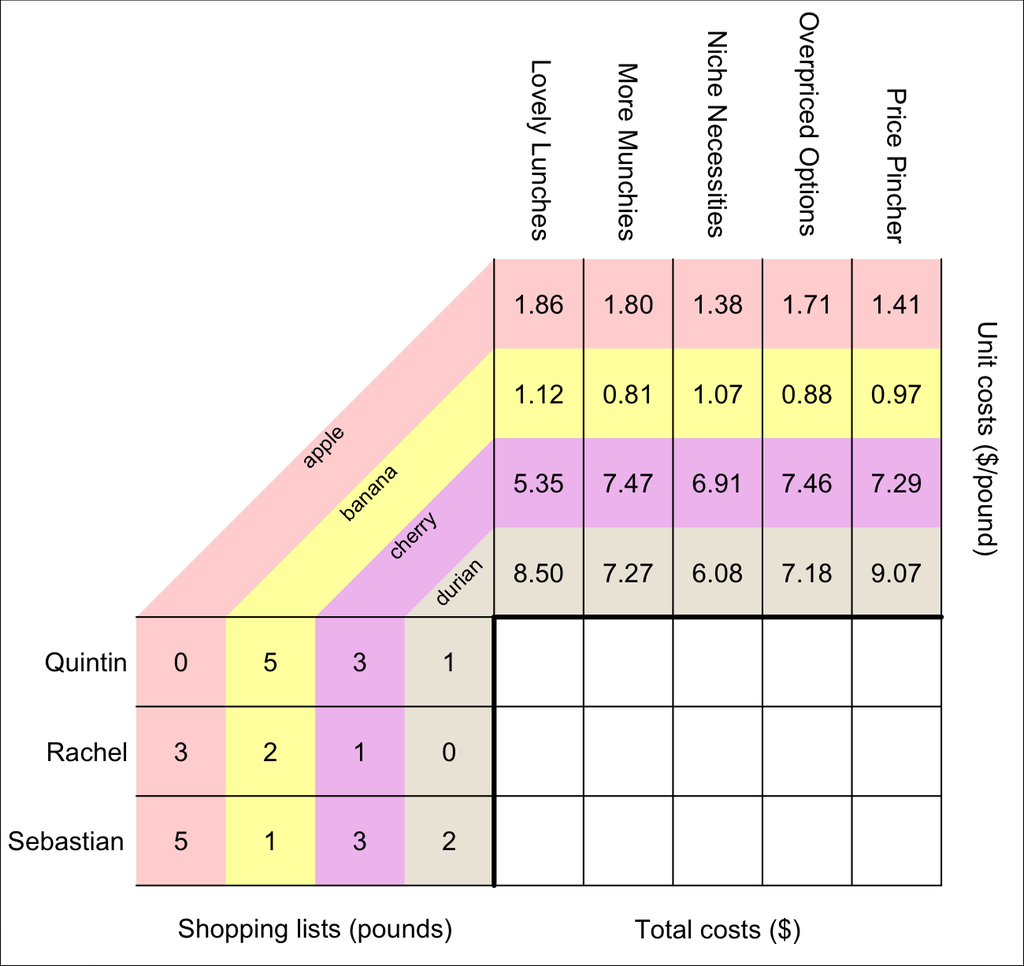

What is the total cost of Quintin shopping at Price Pincher?

Quintin wishes to buy 0 lb of apple, 5 lb of banana, 3 lb of cherry, and 1 lb of durian. At Price Pincher, the unit price of apple is $1.41/lb, the unit price of banana is $0.97/lb, the unit price of cherry is $7.29/lb, and the unit price of durian is $9.07/lb.

To find the total cost of Quintin's shopping trip, multiply each quantity by its corresponding unit price and then add up all those products.

$$(0\cdot1.41)~+~(5\cdot0.97)~+~(3\cdot7.29)~+~(1\cdot9.07)$$
$$0~+~4.85~+~21.87~+~9.07$$
$$35.79$$

So, the total cost of Quintin shopping at Price Pincher is $35.79.

In standard math notation, the matrix multiplication would be shown as:

$$\begin{bmatrix}
0 & 5 & 3 & 1\\
3 & 2 & 1 & 0\\
5 & 1 & 3 & 2
\end{bmatrix} \cdot \begin{bmatrix}
1.86 & 1.8 & 1.38 & 1.71 & 1.41\\
1.12 & 0.81 & 1.07 & 0.88 & 0.97\\
5.35 & 7.47 & 6.91 & 7.46 & 7.29\\
8.5 & 7.27 & 6.08 & 7.18 & 9.07
\end{bmatrix} ~=~ \begin{bmatrix}
30.15 & 33.73 & 32.16 & 33.96 & 35.79\\
13.17 & 14.49 & 13.19 & 14.35 & 13.46\\
43.47 & 46.76 & 40.86 & 46.17 & 48.03
\end{bmatrix}$$

Three people are buying fruit, and there are five grocery stores. Each person has a shopping list dictating how many pounds of each fruit to buy. Each store has different unit costs of fruit.

In order to consider the **total** cost for each person at each store, we can use [matrix multiplication](https://en.wikipedia.org/wiki/Matrix_multiplication). In order to help visualize matrix multiplication, the shopping lists are shown as a matrix on the bottom-left, the unit prices as a matrix on top-right, and the resulting (unfilled) matrix of totals in the bottom-right.

A peculiarity of matrix multiplication requires the **columns** of the first matrix to "match" the **rows** of the second matrix. In this case, notice the various fruits correspond to columns in the first matrix (bottom-left) and rows in the second matrix (top-right). This visualization is an attempt to make this seem more natural.

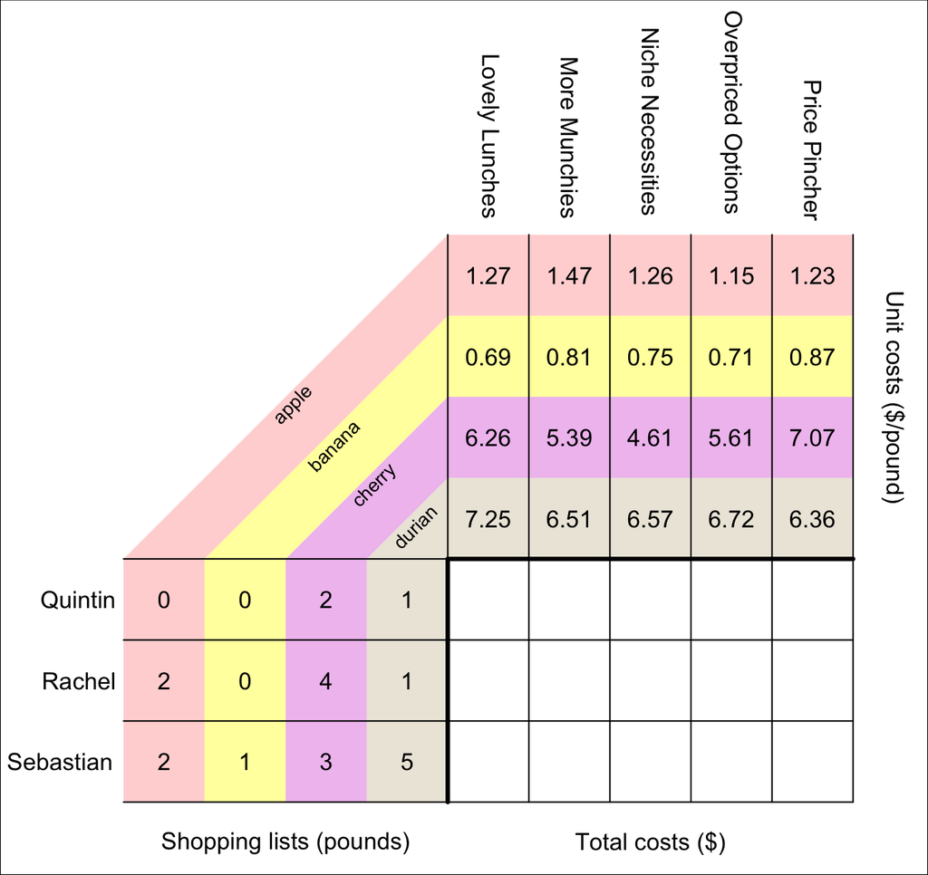

What is the total cost of Rachel shopping at More Munchies?

Rachel wishes to buy 2 lb of apple, 0 lb of banana, 4 lb of cherry, and 1 lb of durian. At More Munchies, the unit price of apple is $1.47/lb, the unit price of banana is $0.81/lb, the unit price of cherry is $5.39/lb, and the unit price of durian is $6.51/lb.

To find the total cost of Rachel's shopping trip, multiply each quantity by its corresponding unit price and then add up all those products.

$$(2\cdot1.47)~+~(0\cdot0.81)~+~(4\cdot5.39)~+~(1\cdot6.51)$$
$$2.94~+~0~+~21.56~+~6.51$$
$$31.01$$

So, the total cost of Rachel shopping at More Munchies is $31.01.

In standard math notation, the matrix multiplication would be shown as:

$$\begin{bmatrix}
0 & 0 & 2 & 1\\
2 & 0 & 4 & 1\\
2 & 1 & 3 & 5
\end{bmatrix} \cdot \begin{bmatrix}
1.27 & 1.47 & 1.26 & 1.15 & 1.23\\
0.69 & 0.81 & 0.75 & 0.71 & 0.87\\
6.26 & 5.39 & 4.61 & 5.61 & 7.07\\
7.25 & 6.51 & 6.57 & 6.72 & 6.36
\end{bmatrix} ~=~ \begin{bmatrix}
19.77 & 17.29 & 15.79 & 17.94 & 20.5\\
34.83 & 31.01 & 27.53 & 31.46 & 37.1\\
58.26 & 52.47 & 49.95 & 53.44 & 56.34
\end{bmatrix}$$

Three people are buying fruit, and there are five grocery stores. Each person has a shopping list dictating how many pounds of each fruit to buy. Each store has different unit costs of fruit.

In order to consider the **total** cost for each person at each store, we can use [matrix multiplication](https://en.wikipedia.org/wiki/Matrix_multiplication). In order to help visualize matrix multiplication, the shopping lists are shown as a matrix on the bottom-left, the unit prices as a matrix on top-right, and the resulting (unfilled) matrix of totals in the bottom-right.

A peculiarity of matrix multiplication requires the **columns** of the first matrix to "match" the **rows** of the second matrix. In this case, notice the various fruits correspond to columns in the first matrix (bottom-left) and rows in the second matrix (top-right). This visualization is an attempt to make this seem more natural.

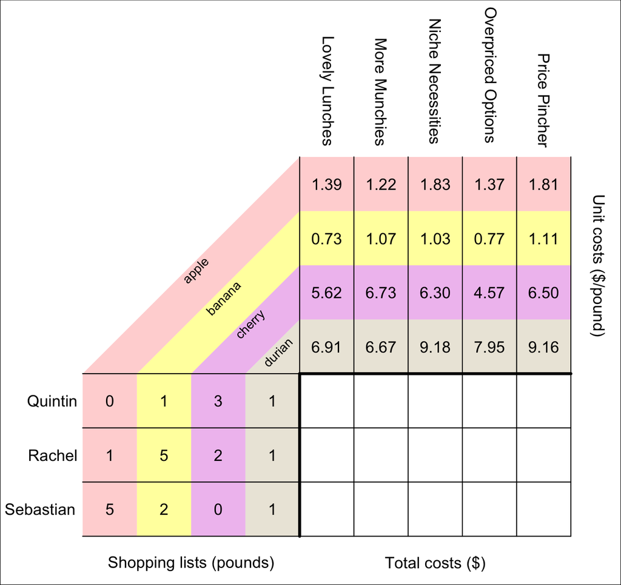

What is the total cost of Sebastian shopping at Lovely Lunches?

Sebastian wishes to buy 5 lb of apple, 2 lb of banana, 0 lb of cherry, and 1 lb of durian. At Lovely Lunches, the unit price of apple is $1.39/lb, the unit price of banana is $0.73/lb, the unit price of cherry is $5.62/lb, and the unit price of durian is $6.91/lb.

To find the total cost of Sebastian's shopping trip, multiply each quantity by its corresponding unit price and then add up all those products.

$$(5\cdot1.39)~+~(2\cdot0.73)~+~(0\cdot5.62)~+~(1\cdot6.91)$$
$$6.95~+~1.46~+~0~+~6.91$$
$$15.32$$

So, the total cost of Sebastian shopping at Lovely Lunches is $15.32.

In standard math notation, the matrix multiplication would be shown as:

$$\begin{bmatrix}
0 & 1 & 3 & 1\\
1 & 5 & 2 & 1\\
5 & 2 & 0 & 1
\end{bmatrix} \cdot \begin{bmatrix}
1.39 & 1.22 & 1.83 & 1.37 & 1.81\\
0.73 & 1.07 & 1.03 & 0.77 & 1.11\\
5.62 & 6.73 & 6.3 & 4.57 & 6.5\\
6.91 & 6.67 & 9.18 & 7.95 & 9.16
\end{bmatrix} ~=~ \begin{bmatrix}
24.5 & 27.93 & 29.11 & 22.43 & 29.77\\
23.19 & 26.7 & 28.76 & 22.31 & 29.52\\
15.32 & 14.91 & 20.39 & 16.34 & 20.43
\end{bmatrix}$$

Three people are buying fruit, and there are five grocery stores. Each person has a shopping list dictating how many pounds of each fruit to buy. Each store has different unit costs of fruit.

In order to consider the **total** cost for each person at each store, we can use [matrix multiplication](https://en.wikipedia.org/wiki/Matrix_multiplication). In order to help visualize matrix multiplication, the shopping lists are shown as a matrix on the bottom-left, the unit prices as a matrix on top-right, and the resulting (unfilled) matrix of totals in the bottom-right.

A peculiarity of matrix multiplication requires the **columns** of the first matrix to "match" the **rows** of the second matrix. In this case, notice the various fruits correspond to columns in the first matrix (bottom-left) and rows in the second matrix (top-right). This visualization is an attempt to make this seem more natural.

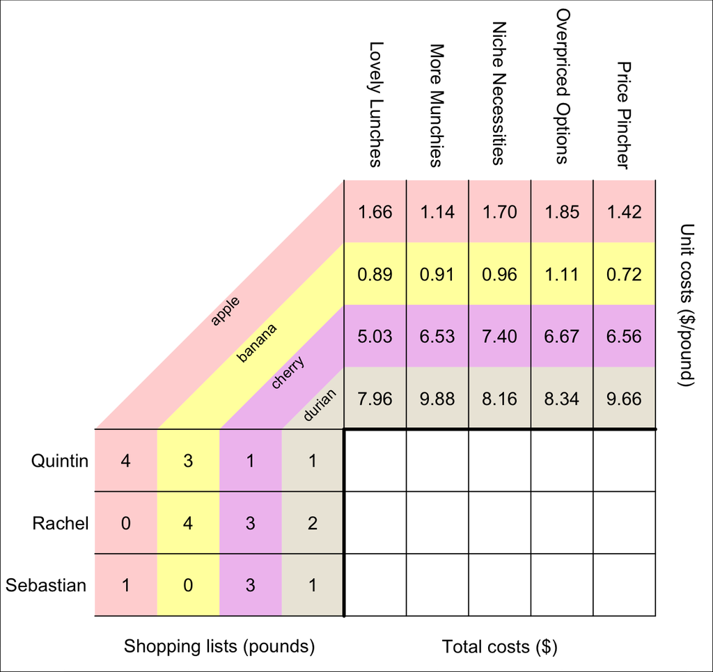

What is the total cost of Sebastian shopping at Niche Necessities?

Sebastian wishes to buy 1 lb of apple, 0 lb of banana, 3 lb of cherry, and 1 lb of durian. At Niche Necessities, the unit price of apple is $1.70/lb, the unit price of banana is $0.96/lb, the unit price of cherry is $7.40/lb, and the unit price of durian is $8.16/lb.

To find the total cost of Sebastian's shopping trip, multiply each quantity by its corresponding unit price and then add up all those products.

$$(1\cdot1.7)~+~(0\cdot0.96)~+~(3\cdot7.4)~+~(1\cdot8.16)$$
$$1.7~+~0~+~22.2~+~8.16$$
$$32.06$$

So, the total cost of Sebastian shopping at Niche Necessities is $32.06.

In standard math notation, the matrix multiplication would be shown as:

$$\begin{bmatrix}
4 & 3 & 1 & 1\\
0 & 4 & 3 & 2\\
1 & 0 & 3 & 1
\end{bmatrix} \cdot \begin{bmatrix}
1.66 & 1.14 & 1.7 & 1.85 & 1.42\\
0.89 & 0.91 & 0.96 & 1.11 & 0.72\\
5.03 & 6.53 & 7.4 & 6.67 & 6.56\\
7.96 & 9.88 & 8.16 & 8.34 & 9.66
\end{bmatrix} ~=~ \begin{bmatrix}
22.3 & 23.7 & 25.24 & 25.74 & 24.06\\
34.57 & 42.99 & 42.36 & 41.13 & 41.88\\
24.71 & 30.61 & 32.06 & 30.2 & 30.76
\end{bmatrix}$$

Three people are buying fruit, and there are five grocery stores. Each person has a shopping list dictating how many pounds of each fruit to buy. Each store has different unit costs of fruit.

In order to consider the **total** cost for each person at each store, we can use [matrix multiplication](https://en.wikipedia.org/wiki/Matrix_multiplication). In order to help visualize matrix multiplication, the shopping lists are shown as a matrix on the bottom-left, the unit prices as a matrix on top-right, and the resulting (unfilled) matrix of totals in the bottom-right.

A peculiarity of matrix multiplication requires the **columns** of the first matrix to "match" the **rows** of the second matrix. In this case, notice the various fruits correspond to columns in the first matrix (bottom-left) and rows in the second matrix (top-right). This visualization is an attempt to make this seem more natural.

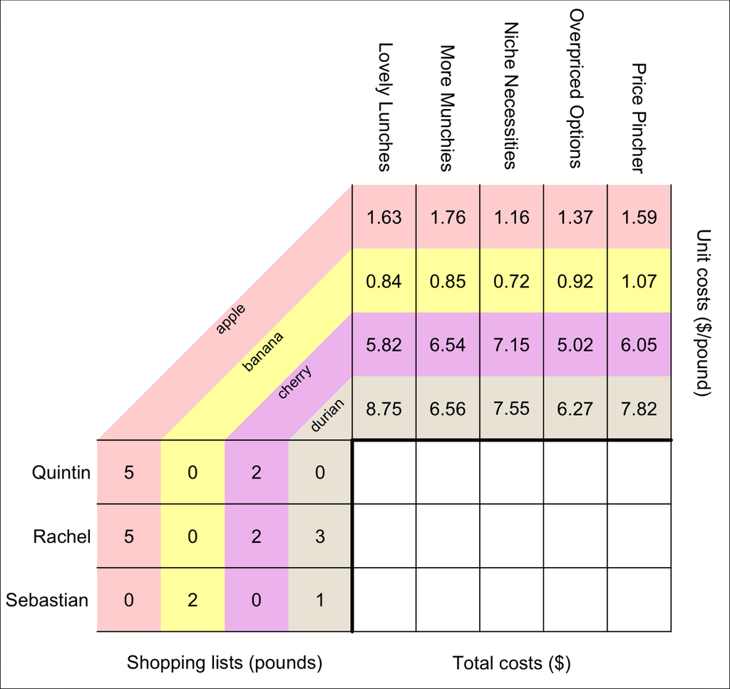

What is the total cost of Quintin shopping at Niche Necessities?

Quintin wishes to buy 5 lb of apple, 0 lb of banana, 2 lb of cherry, and 0 lb of durian. At Niche Necessities, the unit price of apple is $1.16/lb, the unit price of banana is $0.72/lb, the unit price of cherry is $7.15/lb, and the unit price of durian is $7.55/lb.

To find the total cost of Quintin's shopping trip, multiply each quantity by its corresponding unit price and then add up all those products.

$$(5\cdot1.16)~+~(0\cdot0.72)~+~(2\cdot7.15)~+~(0\cdot7.55)$$
$$5.8~+~0~+~14.3~+~0$$
$$20.10$$

So, the total cost of Quintin shopping at Niche Necessities is $20.10.

In standard math notation, the matrix multiplication would be shown as:

$$\begin{bmatrix}
5 & 0 & 2 & 0\\
5 & 0 & 2 & 3\\
0 & 2 & 0 & 1
\end{bmatrix} \cdot \begin{bmatrix}
1.63 & 1.76 & 1.16 & 1.37 & 1.59\\
0.84 & 0.85 & 0.72 & 0.92 & 1.07\\
5.82 & 6.54 & 7.15 & 5.02 & 6.05\\
8.75 & 6.56 & 7.55 & 6.27 & 7.82
\end{bmatrix} ~=~ \begin{bmatrix}
19.79 & 21.88 & 20.1 & 16.89 & 20.05\\
46.04 & 41.56 & 42.75 & 35.7 & 43.51\\
10.43 & 8.26 & 8.99 & 8.11 & 9.96
\end{bmatrix}$$

Three people are buying fruit, and there are five grocery stores. Each person has a shopping list dictating how many pounds of each fruit to buy. Each store has different unit costs of fruit.

In order to consider the **total** cost for each person at each store, we can use [matrix multiplication](https://en.wikipedia.org/wiki/Matrix_multiplication). In order to help visualize matrix multiplication, the shopping lists are shown as a matrix on the bottom-left, the unit prices as a matrix on top-right, and the resulting (unfilled) matrix of totals in the bottom-right.

A peculiarity of matrix multiplication requires the **columns** of the first matrix to "match" the **rows** of the second matrix. In this case, notice the various fruits correspond to columns in the first matrix (bottom-left) and rows in the second matrix (top-right). This visualization is an attempt to make this seem more natural.

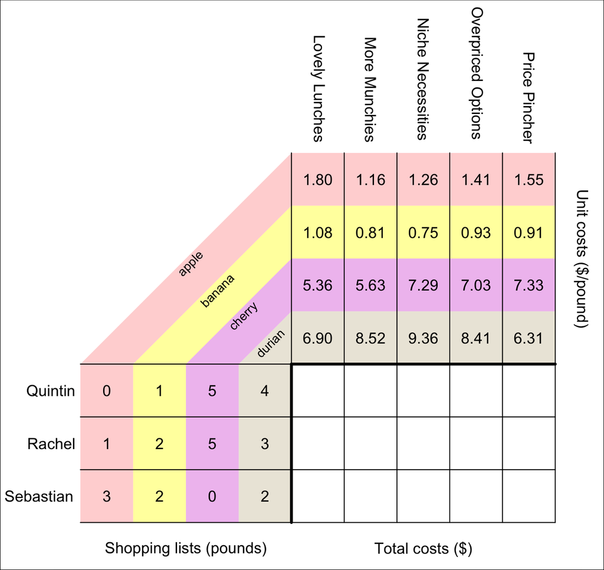

What is the total cost of Sebastian shopping at Overpriced Options?

Sebastian wishes to buy 3 lb of apple, 2 lb of banana, 0 lb of cherry, and 2 lb of durian. At Overpriced Options, the unit price of apple is $1.41/lb, the unit price of banana is $0.93/lb, the unit price of cherry is $7.03/lb, and the unit price of durian is $8.41/lb.

To find the total cost of Sebastian's shopping trip, multiply each quantity by its corresponding unit price and then add up all those products.

$$(3\cdot1.41)~+~(2\cdot0.93)~+~(0\cdot7.03)~+~(2\cdot8.41)$$
$$4.23~+~1.86~+~0~+~16.82$$
$$22.91$$

So, the total cost of Sebastian shopping at Overpriced Options is $22.91.

In standard math notation, the matrix multiplication would be shown as:

$$\begin{bmatrix}
0 & 1 & 5 & 4\\
1 & 2 & 5 & 3\\
3 & 2 & 0 & 2
\end{bmatrix} \cdot \begin{bmatrix}
1.8 & 1.16 & 1.26 & 1.41 & 1.55\\
1.08 & 0.81 & 0.75 & 0.93 & 0.91\\
5.36 & 5.63 & 7.29 & 7.03 & 7.33\\
6.9 & 8.52 & 9.36 & 8.41 & 6.31
\end{bmatrix} ~=~ \begin{bmatrix}
55.48 & 63.04 & 74.64 & 69.72 & 62.8\\
51.46 & 56.49 & 67.29 & 63.65 & 58.95\\
21.36 & 22.14 & 24 & 22.91 & 19.09
\end{bmatrix}$$

Three people are buying fruit, and there are five grocery stores. Each person has a shopping list dictating how many pounds of each fruit to buy. Each store has different unit costs of fruit.

In order to consider the **total** cost for each person at each store, we can use [matrix multiplication](https://en.wikipedia.org/wiki/Matrix_multiplication). In order to help visualize matrix multiplication, the shopping lists are shown as a matrix on the bottom-left, the unit prices as a matrix on top-right, and the resulting (unfilled) matrix of totals in the bottom-right.

A peculiarity of matrix multiplication requires the **columns** of the first matrix to "match" the **rows** of the second matrix. In this case, notice the various fruits correspond to columns in the first matrix (bottom-left) and rows in the second matrix (top-right). This visualization is an attempt to make this seem more natural.

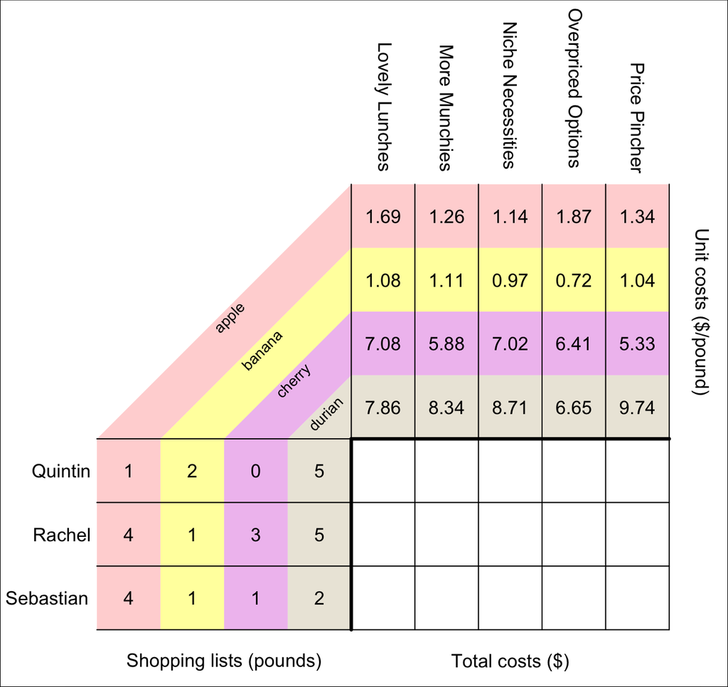

What is the total cost of Quintin shopping at Niche Necessities?

Quintin wishes to buy 1 lb of apple, 2 lb of banana, 0 lb of cherry, and 5 lb of durian. At Niche Necessities, the unit price of apple is $1.14/lb, the unit price of banana is $0.97/lb, the unit price of cherry is $7.02/lb, and the unit price of durian is $8.71/lb.

To find the total cost of Quintin's shopping trip, multiply each quantity by its corresponding unit price and then add up all those products.

$$(1\cdot1.14)~+~(2\cdot0.97)~+~(0\cdot7.02)~+~(5\cdot8.71)$$
$$1.14~+~1.94~+~0~+~43.55$$
$$46.63$$

So, the total cost of Quintin shopping at Niche Necessities is $46.63.

In standard math notation, the matrix multiplication would be shown as:

$$\begin{bmatrix}
1 & 2 & 0 & 5\\
4 & 1 & 3 & 5\\
4 & 1 & 1 & 2
\end{bmatrix} \cdot \begin{bmatrix}
1.69 & 1.26 & 1.14 & 1.87 & 1.34\\
1.08 & 1.11 & 0.97 & 0.72 & 1.04\\
7.08 & 5.88 & 7.02 & 6.41 & 5.33\\
7.86 & 8.34 & 8.71 & 6.65 & 9.74
\end{bmatrix} ~=~ \begin{bmatrix}
43.15 & 45.18 & 46.63 & 36.56 & 52.12\\
68.38 & 65.49 & 70.14 & 60.68 & 71.09\\
30.64 & 28.71 & 29.97 & 27.91 & 31.21
\end{bmatrix}$$

Three people are buying fruit, and there are five grocery stores. Each person has a shopping list dictating how many pounds of each fruit to buy. Each store has different unit costs of fruit.

In order to consider the **total** cost for each person at each store, we can use [matrix multiplication](https://en.wikipedia.org/wiki/Matrix_multiplication). In order to help visualize matrix multiplication, the shopping lists are shown as a matrix on the bottom-left, the unit prices as a matrix on top-right, and the resulting (unfilled) matrix of totals in the bottom-right.

A peculiarity of matrix multiplication requires the **columns** of the first matrix to "match" the **rows** of the second matrix. In this case, notice the various fruits correspond to columns in the first matrix (bottom-left) and rows in the second matrix (top-right). This visualization is an attempt to make this seem more natural.

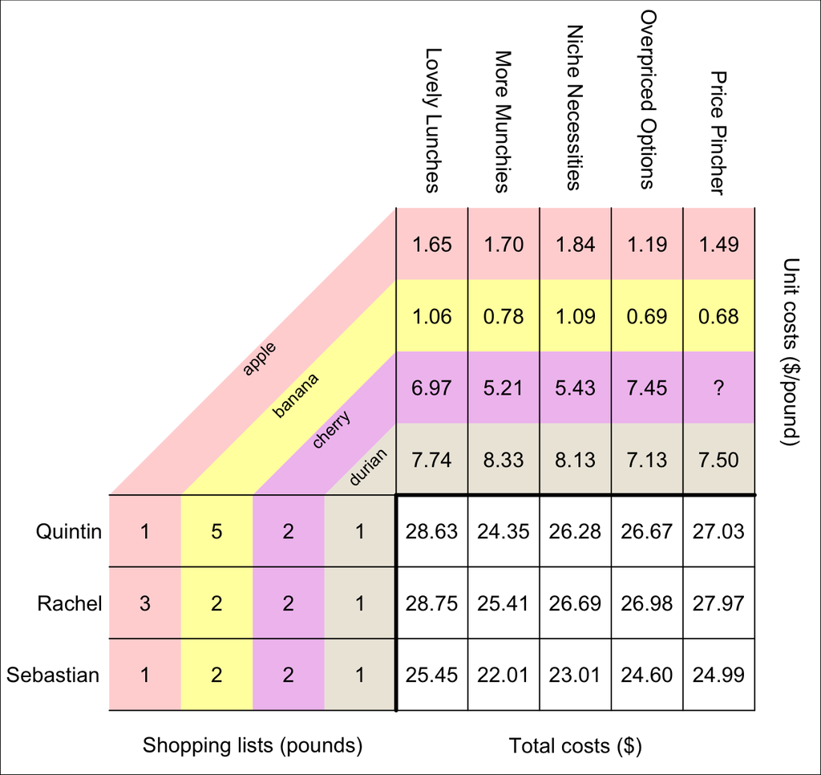

What is the unit cost of cherries, in dollars per pound, at Price Pincher?

You can use any person's shopping trip at Price Pincher. Use $x$ to represent the unknown unit cost.

- If you use Quintin, solve the following equation:

$$(1\cdot 1.49)+(5\cdot 0.68)+(2\cdot
x)+(1\cdot 7.5)=27.03$$

- If you use Rachel, solve the following equation:

$$(3\cdot 1.49)+(2\cdot 0.68)+(2\cdot
x)+(1\cdot 7.5)=27.97$$

- If you use Sebastian, solve the following equation:

$$(1\cdot 1.49)+(2\cdot 0.68)+(2\cdot
x)+(1\cdot 7.5)=24.99$$

Any equation solves to give $x=7.32$. Thus, the unit price of cherries at Price Pincher is $7.32 per pound.

Three people are buying fruit, and there are five grocery stores. Each person has a shopping list dictating how many pounds of each fruit to buy. Each store has different unit costs of fruit.

A peculiarity of matrix multiplication requires the **columns** of the first matrix to "match" the **rows** of the second matrix. In this case, notice the various fruits correspond to columns in the first matrix (bottom-left) and rows in the second matrix (top-right). This visualization is an attempt to make this seem more natural.

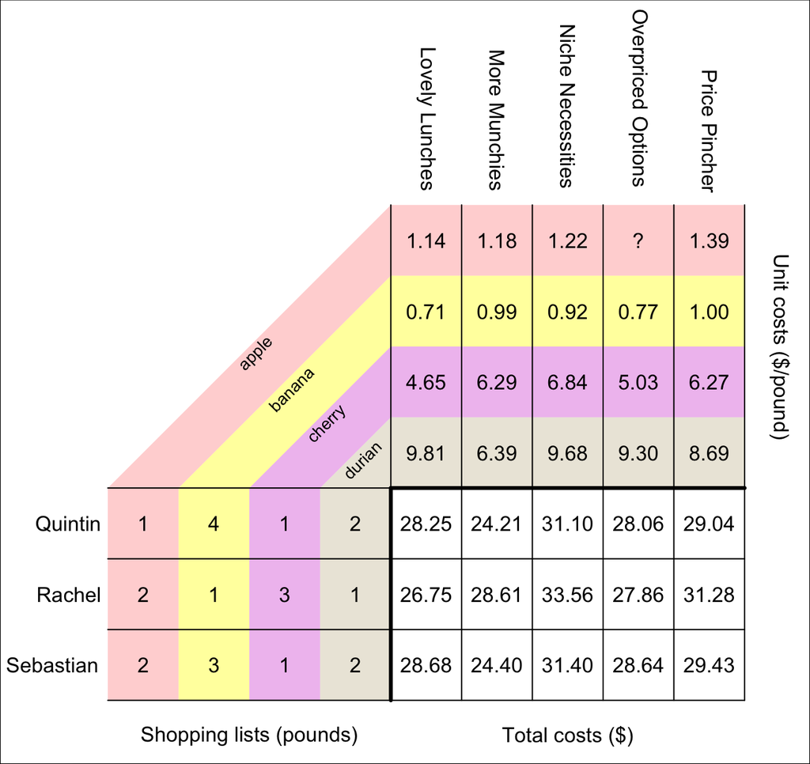

What is the unit cost of apples, in dollars per pound, at Overpriced Options?

You can use any person's shopping trip at Overpriced Options. Use $x$ to represent the unknown unit cost.

- If you use Quintin, solve the following equation:

$$(1\cdot x)+(4\cdot 0.77)+(1\cdot
5.03)+(2\cdot 9.3)=28.06$$

- If you use Rachel, solve the following equation:

$$(2\cdot x)+(1\cdot 0.77)+(3\cdot
5.03)+(1\cdot 9.3)=27.86$$

- If you use Sebastian, solve the following equation:

$$(2\cdot x)+(3\cdot 0.77)+(1\cdot
5.03)+(2\cdot 9.3)=28.64$$

Any equation solves to give $x=1.35$. Thus, the unit price of apples at Overpriced Options is $1.35 per pound.

Three people are buying fruit, and there are five grocery stores. Each person has a shopping list dictating how many pounds of each fruit to buy. Each store has different unit costs of fruit.

A peculiarity of matrix multiplication requires the **columns** of the first matrix to "match" the **rows** of the second matrix. In this case, notice the various fruits correspond to columns in the first matrix (bottom-left) and rows in the second matrix (top-right). This visualization is an attempt to make this seem more natural.

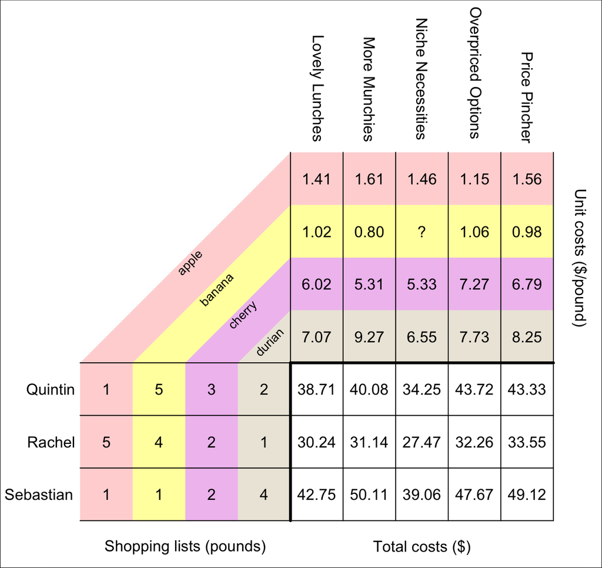

What is the unit cost of bananas, in dollars per pound, at Niche Necessities?

You can use any person's shopping trip at Niche Necessities. Use $x$ to represent the unknown unit cost.

- If you use Quintin, solve the following equation:

$$(1\cdot 1.46)+(5\cdot x)+(3\cdot
5.33)+(2\cdot 6.55)=34.25$$

- If you use Rachel, solve the following equation:

$$(5\cdot 1.46)+(4\cdot x)+(2\cdot
5.33)+(1\cdot 6.55)=27.47$$

- If you use Sebastian, solve the following equation:

$$(1\cdot 1.46)+(1\cdot x)+(2\cdot
5.33)+(4\cdot 6.55)=39.06$$

Any equation solves to give $x=0.74$. Thus, the unit price of bananas at Niche Necessities is $0.74 per pound.

Three people are buying fruit, and there are five grocery stores. Each person has a shopping list dictating how many pounds of each fruit to buy. Each store has different unit costs of fruit.

A peculiarity of matrix multiplication requires the **columns** of the first matrix to "match" the **rows** of the second matrix. In this case, notice the various fruits correspond to columns in the first matrix (bottom-left) and rows in the second matrix (top-right). This visualization is an attempt to make this seem more natural.

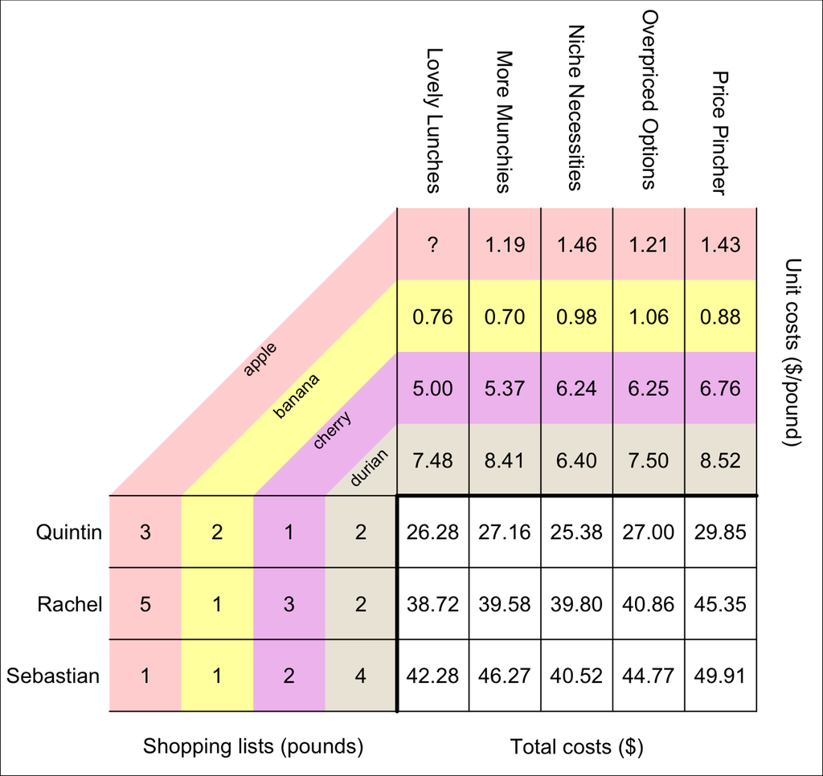

What is the unit cost of apples, in dollars per pound, at Lovely Lunches?

You can use any person's shopping trip at Lovely Lunches. Use $x$ to represent the unknown unit cost.

- If you use Quintin, solve the following equation:

$$(3\cdot x)+(2\cdot 0.76)+(1\cdot
5)+(2\cdot 7.48)=26.28$$

- If you use Rachel, solve the following equation:

$$(5\cdot x)+(1\cdot 0.76)+(3\cdot
5)+(2\cdot 7.48)=38.72$$

- If you use Sebastian, solve the following equation:

$$(1\cdot x)+(1\cdot 0.76)+(2\cdot
5)+(4\cdot 7.48)=42.28$$

Any equation solves to give $x=1.6$. Thus, the unit price of apples at Lovely Lunches is $1.60 per pound.

Three people are buying fruit, and there are five grocery stores. Each person has a shopping list dictating how many pounds of each fruit to buy. Each store has different unit costs of fruit.

A peculiarity of matrix multiplication requires the **columns** of the first matrix to "match" the **rows** of the second matrix. In this case, notice the various fruits correspond to columns in the first matrix (bottom-left) and rows in the second matrix (top-right). This visualization is an attempt to make this seem more natural.

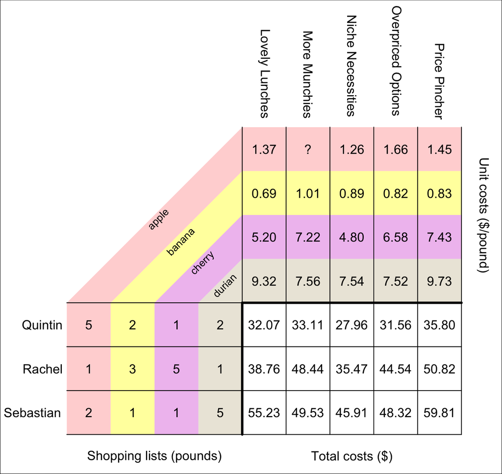

What is the unit cost of apples, in dollars per pound, at More Munchies?

You can use any person's shopping trip at More Munchies. Use $x$ to represent the unknown unit cost.

- If you use Quintin, solve the following equation:

$$(5\cdot x)+(2\cdot 1.01)+(1\cdot
7.22)+(2\cdot 7.56)=33.11$$

- If you use Rachel, solve the following equation:

$$(1\cdot x)+(3\cdot 1.01)+(5\cdot
7.22)+(1\cdot 7.56)=48.44$$

- If you use Sebastian, solve the following equation:

$$(2\cdot x)+(1\cdot 1.01)+(1\cdot
7.22)+(5\cdot 7.56)=49.53$$

Any equation solves to give $x=1.75$. Thus, the unit price of apples at More Munchies is $1.75 per pound.

Three people are buying fruit, and there are five grocery stores. Each person has a shopping list dictating how many pounds of each fruit to buy. Each store has different unit costs of fruit.

A peculiarity of matrix multiplication requires the **columns** of the first matrix to "match" the **rows** of the second matrix. In this case, notice the various fruits correspond to columns in the first matrix (bottom-left) and rows in the second matrix (top-right). This visualization is an attempt to make this seem more natural.

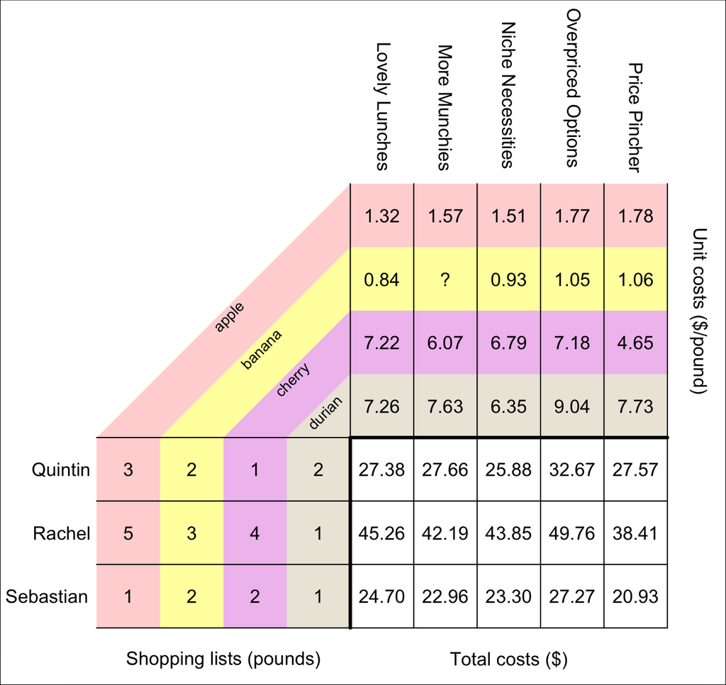

What is the unit cost of bananas, in dollars per pound, at More Munchies?

You can use any person's shopping trip at More Munchies. Use $x$ to represent the unknown unit cost.

- If you use Quintin, solve the following equation:

$$(3\cdot 1.57)+(2\cdot x)+(1\cdot
6.07)+(2\cdot 7.63)=27.66$$

- If you use Rachel, solve the following equation:

$$(5\cdot 1.57)+(3\cdot x)+(4\cdot
6.07)+(1\cdot 7.63)=42.19$$

- If you use Sebastian, solve the following equation:

$$(1\cdot 1.57)+(2\cdot x)+(2\cdot
6.07)+(1\cdot 7.63)=22.96$$

Any equation solves to give $x=0.81$. Thus, the unit price of bananas at More Munchies is $0.81 per pound.

Three people are buying fruit, and there are five grocery stores. Each person has a shopping list dictating how many pounds of each fruit to buy. Each store has different unit costs of fruit.

A peculiarity of matrix multiplication requires the **columns** of the first matrix to "match" the **rows** of the second matrix. In this case, notice the various fruits correspond to columns in the first matrix (bottom-left) and rows in the second matrix (top-right). This visualization is an attempt to make this seem more natural.

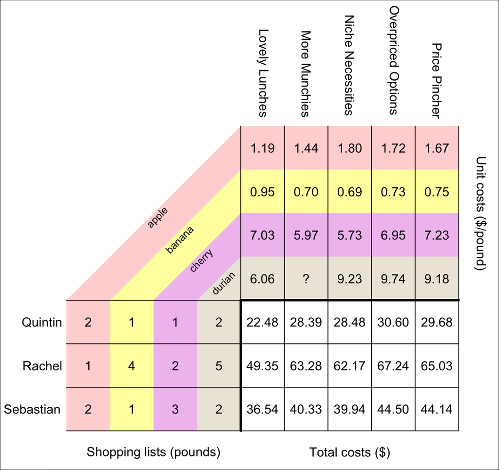

What is the unit cost of durian, in dollars per pound, at More Munchies?

You can use any person's shopping trip at More Munchies. Use $x$ to represent the unknown unit cost.

- If you use Quintin, solve the following equation:

$$(2\cdot 1.44)+(1\cdot 0.7)+(1\cdot
5.97)+(2\cdot x)=28.39$$

- If you use Rachel, solve the following equation:

$$(1\cdot 1.44)+(4\cdot 0.7)+(2\cdot
5.97)+(5\cdot x)=63.28$$

- If you use Sebastian, solve the following equation:

$$(2\cdot 1.44)+(1\cdot 0.7)+(3\cdot
5.97)+(2\cdot x)=40.33$$

Any equation solves to give $x=9.42$. Thus, the unit price of durian at More Munchies is $9.42 per pound.

Three people are buying fruit, and there are five grocery stores. Each person has a shopping list dictating how many pounds of each fruit to buy. Each store has different unit costs of fruit.

A peculiarity of matrix multiplication requires the **columns** of the first matrix to "match" the **rows** of the second matrix. In this case, notice the various fruits correspond to columns in the first matrix (bottom-left) and rows in the second matrix (top-right). This visualization is an attempt to make this seem more natural.

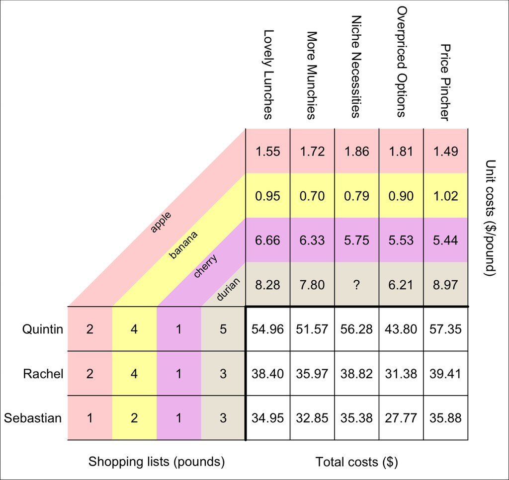

What is the unit cost of durian, in dollars per pound, at Niche Necessities?

You can use any person's shopping trip at Niche Necessities. Use $x$ to represent the unknown unit cost.

- If you use Quintin, solve the following equation:

$$(2\cdot 1.86)+(4\cdot 0.79)+(1\cdot
5.75)+(5\cdot x)=56.28$$

- If you use Rachel, solve the following equation:

$$(2\cdot 1.86)+(4\cdot 0.79)+(1\cdot
5.75)+(3\cdot x)=38.82$$

- If you use Sebastian, solve the following equation:

$$(1\cdot 1.86)+(2\cdot 0.79)+(1\cdot
5.75)+(3\cdot x)=35.38$$

Any equation solves to give $x=8.73$. Thus, the unit price of durian at Niche Necessities is $8.73 per pound.

Three people are buying fruit, and there are five grocery stores. Each person has a shopping list dictating how many pounds of each fruit to buy. Each store has different unit costs of fruit.

A peculiarity of matrix multiplication requires the **columns** of the first matrix to "match" the **rows** of the second matrix. In this case, notice the various fruits correspond to columns in the first matrix (bottom-left) and rows in the second matrix (top-right). This visualization is an attempt to make this seem more natural.

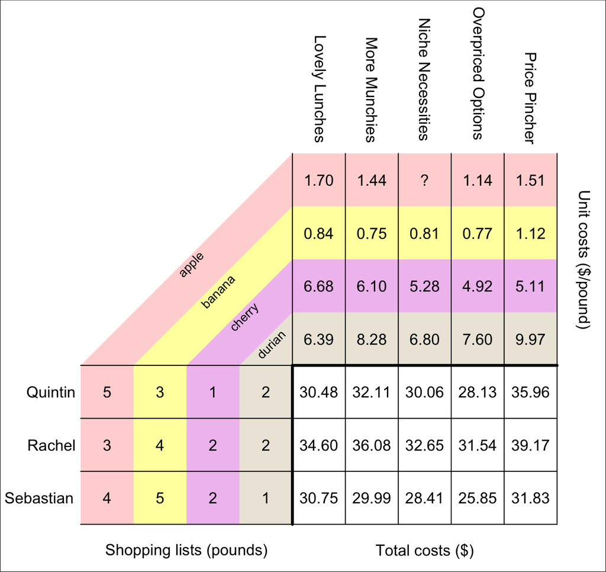

What is the unit cost of apples, in dollars per pound, at Niche Necessities?

You can use any person's shopping trip at Niche Necessities. Use $x$ to represent the unknown unit cost.

- If you use Quintin, solve the following equation:

$$(5\cdot x)+(3\cdot 0.81)+(1\cdot
5.28)+(2\cdot 6.8)=30.06$$

- If you use Rachel, solve the following equation:

$$(3\cdot x)+(4\cdot 0.81)+(2\cdot
5.28)+(2\cdot 6.8)=32.65$$

- If you use Sebastian, solve the following equation:

$$(4\cdot x)+(5\cdot 0.81)+(2\cdot
5.28)+(1\cdot 6.8)=28.41$$

Any equation solves to give $x=1.75$. Thus, the unit price of apples at Niche Necessities is $1.75 per pound.

Three people are buying fruit, and there are five grocery stores. Each person has a shopping list dictating how many pounds of each fruit to buy. Each store has different unit costs of fruit.

A peculiarity of matrix multiplication requires the **columns** of the first matrix to "match" the **rows** of the second matrix. In this case, notice the various fruits correspond to columns in the first matrix (bottom-left) and rows in the second matrix (top-right). This visualization is an attempt to make this seem more natural.

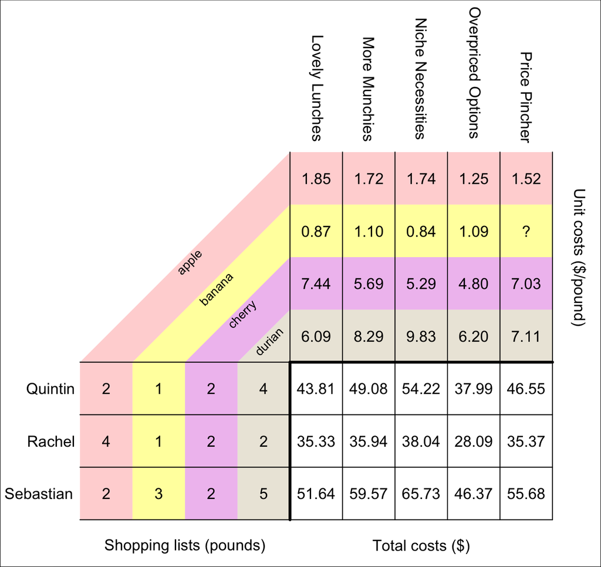

What is the unit cost of bananas, in dollars per pound, at Price Pincher?

You can use any person's shopping trip at Price Pincher. Use $x$ to represent the unknown unit cost.

- If you use Quintin, solve the following equation:

$$(2\cdot 1.52)+(1\cdot x)+(2\cdot
7.03)+(4\cdot 7.11)=46.55$$

- If you use Rachel, solve the following equation:

$$(4\cdot 1.52)+(1\cdot x)+(2\cdot
7.03)+(2\cdot 7.11)=35.37$$

- If you use Sebastian, solve the following equation:

$$(2\cdot 1.52)+(3\cdot x)+(2\cdot
7.03)+(5\cdot 7.11)=55.68$$

Any equation solves to give $x=1.01$. Thus, the unit price of bananas at Price Pincher is $1.01 per pound.

Three people are buying fruit, and there are five grocery stores. Each person has a shopping list dictating how many pounds of each fruit to buy. Each store has different unit costs of fruit.

A peculiarity of matrix multiplication requires the **columns** of the first matrix to "match" the **rows** of the second matrix. In this case, notice the various fruits correspond to columns in the first matrix (bottom-left) and rows in the second matrix (top-right). This visualization is an attempt to make this seem more natural.

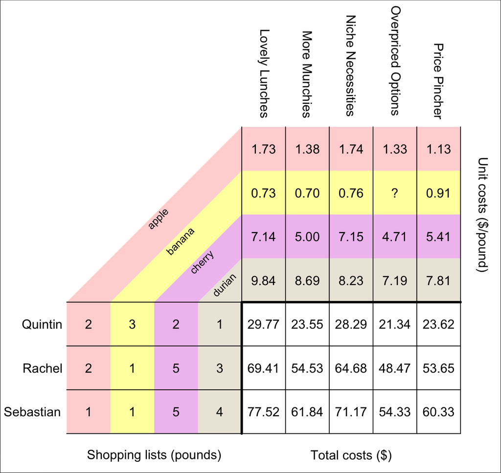

What is the unit cost of bananas, in dollars per pound, at Overpriced Options?

You can use any person's shopping trip at Overpriced Options. Use $x$ to represent the unknown unit cost.

- If you use Quintin, solve the following equation:

$$(2\cdot 1.33)+(3\cdot x)+(2\cdot
4.71)+(1\cdot 7.19)=21.34$$

- If you use Rachel, solve the following equation:

$$(2\cdot 1.33)+(1\cdot x)+(5\cdot
4.71)+(3\cdot 7.19)=48.47$$

- If you use Sebastian, solve the following equation:

$$(1\cdot 1.33)+(1\cdot x)+(5\cdot
4.71)+(4\cdot 7.19)=54.33$$

Any equation solves to give $x=0.69$. Thus, the unit price of bananas at Overpriced Options is $0.69 per pound.

Three people are buying fruit, and there are five grocery stores. Each person has a shopping list dictating how many pounds of each fruit to buy. Each store has different unit costs of fruit.

A peculiarity of matrix multiplication requires the **columns** of the first matrix to "match" the **rows** of the second matrix. In this case, notice the various fruits correspond to columns in the first matrix (bottom-left) and rows in the second matrix (top-right). This visualization is an attempt to make this seem more natural.

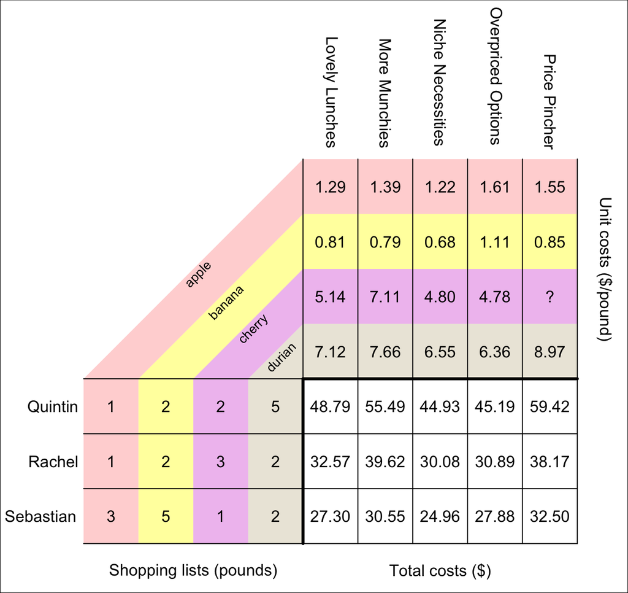

What is the unit cost of cherries, in dollars per pound, at Price Pincher?

You can use any person's shopping trip at Price Pincher. Use $x$ to represent the unknown unit cost.

- If you use Quintin, solve the following equation:

$$(1\cdot 1.55)+(2\cdot 0.85)+(2\cdot
x)+(5\cdot 8.97)=59.42$$

- If you use Rachel, solve the following equation:

$$(1\cdot 1.55)+(2\cdot 0.85)+(3\cdot
x)+(2\cdot 8.97)=38.17$$

- If you use Sebastian, solve the following equation:

$$(3\cdot 1.55)+(5\cdot 0.85)+(1\cdot
x)+(2\cdot 8.97)=32.5$$

Any equation solves to give $x=5.66$. Thus, the unit price of cherries at Price Pincher is $5.66 per pound.

Three people are buying fruit, and there are five grocery stores. Each person has a shopping list dictating how many pounds of each fruit to buy. Each store has different unit costs of fruit.

A peculiarity of matrix multiplication requires the **columns** of the first matrix to "match" the **rows** of the second matrix. In this case, notice the various fruits correspond to columns in the first matrix (bottom-left) and rows in the second matrix (top-right). This visualization is an attempt to make this seem more natural.

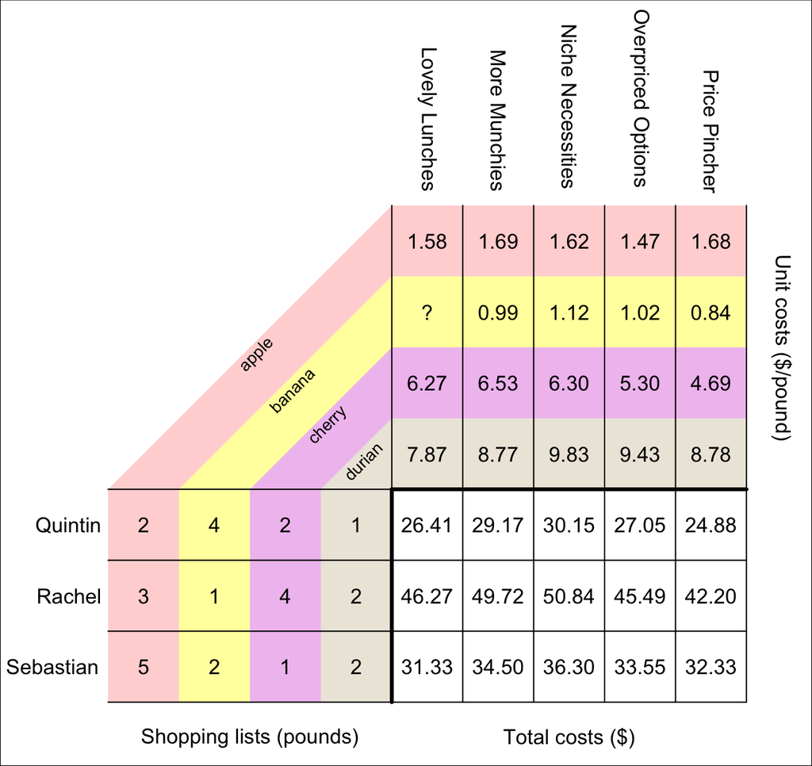

What is the unit cost of bananas, in dollars per pound, at Lovely Lunches?

You can use any person's shopping trip at Lovely Lunches. Use $x$ to represent the unknown unit cost.

- If you use Quintin, solve the following equation:

$$(2\cdot 1.58)+(4\cdot x)+(2\cdot
6.27)+(1\cdot 7.87)=26.41$$

- If you use Rachel, solve the following equation:

$$(3\cdot 1.58)+(1\cdot x)+(4\cdot
6.27)+(2\cdot 7.87)=46.27$$

- If you use Sebastian, solve the following equation:

$$(5\cdot 1.58)+(2\cdot x)+(1\cdot
6.27)+(2\cdot 7.87)=31.33$$

Any equation solves to give $x=0.71$. Thus, the unit price of bananas at Lovely Lunches is $0.71 per pound.

Three people are buying fruit, and there are five grocery stores. Each person has a shopping list dictating how many pounds of each fruit to buy. Each store has different unit costs of fruit.

A peculiarity of matrix multiplication requires the **columns** of the first matrix to "match" the **rows** of the second matrix. In this case, notice the various fruits correspond to columns in the first matrix (bottom-left) and rows in the second matrix (top-right). This visualization is an attempt to make this seem more natural.

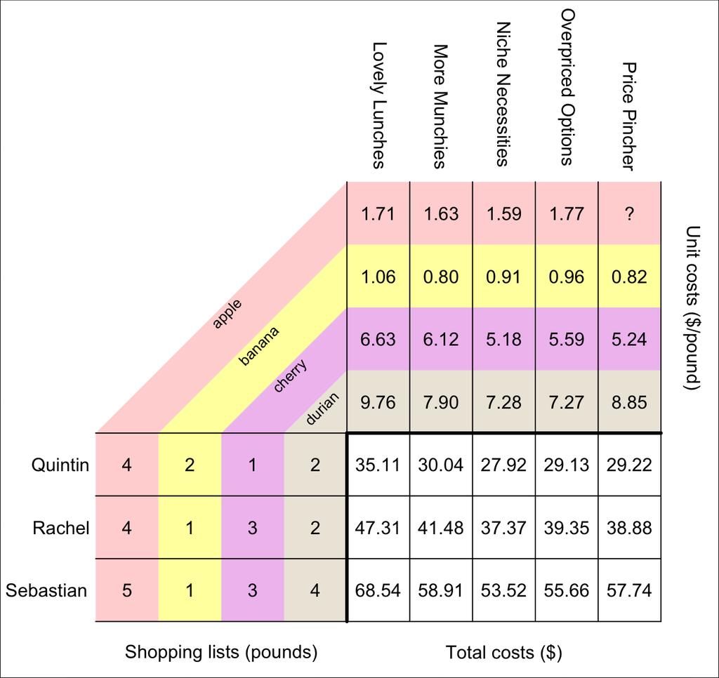

What is the unit cost of apples, in dollars per pound, at Price Pincher?

You can use any person's shopping trip at Price Pincher. Use $x$ to represent the unknown unit cost.

- If you use Quintin, solve the following equation:

$$(4\cdot x)+(2\cdot 0.82)+(1\cdot
5.24)+(2\cdot 8.85)=29.22$$

- If you use Rachel, solve the following equation:

$$(4\cdot x)+(1\cdot 0.82)+(3\cdot
5.24)+(2\cdot 8.85)=38.88$$

- If you use Sebastian, solve the following equation:

$$(5\cdot x)+(1\cdot 0.82)+(3\cdot
5.24)+(4\cdot 8.85)=57.74$$

Any equation solves to give $x=1.16$. Thus, the unit price of apples at Price Pincher is $1.16 per pound.

Three people are buying fruit, and there are five grocery stores. Each person has a shopping list dictating how many pounds of each fruit to buy. Each store has different unit costs of fruit.

A peculiarity of matrix multiplication requires the **columns** of the first matrix to "match" the **rows** of the second matrix. In this case, notice the various fruits correspond to columns in the first matrix (bottom-left) and rows in the second matrix (top-right). This visualization is an attempt to make this seem more natural.

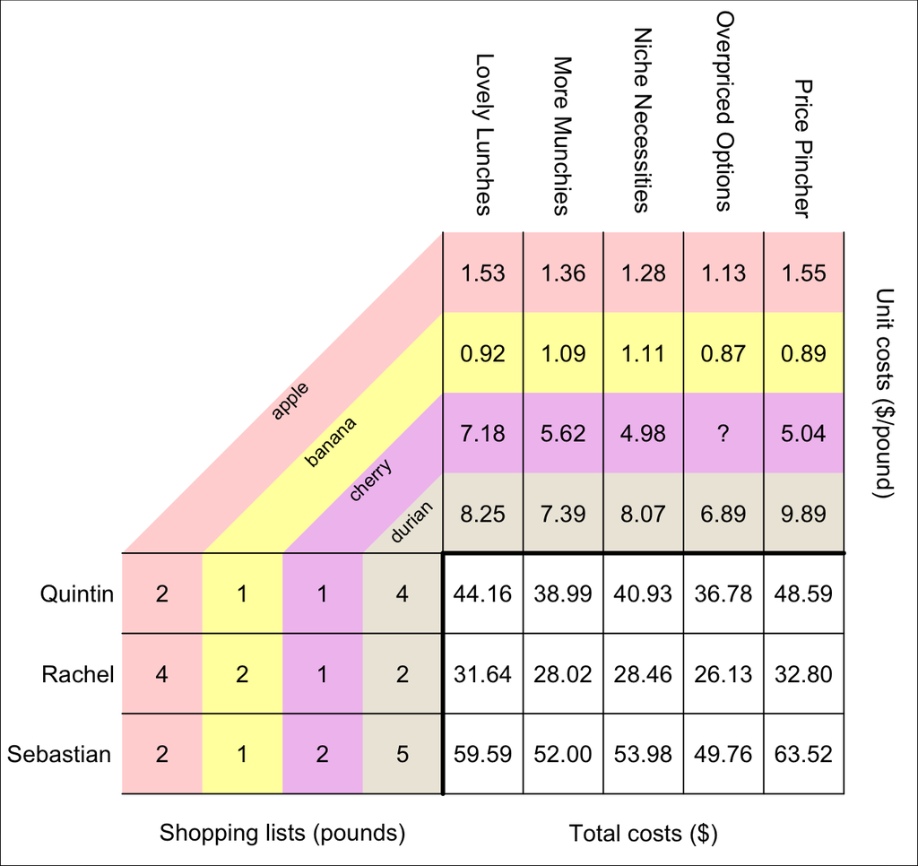

What is the unit cost of cherries, in dollars per pound, at Overpriced Options?

You can use any person's shopping trip at Overpriced Options. Use $x$ to represent the unknown unit cost.

- If you use Quintin, solve the following equation:

$$(2\cdot 1.13)+(1\cdot 0.87)+(1\cdot
x)+(4\cdot 6.89)=36.78$$

- If you use Rachel, solve the following equation:

$$(4\cdot 1.13)+(2\cdot 0.87)+(1\cdot
x)+(2\cdot 6.89)=26.13$$

- If you use Sebastian, solve the following equation:

$$(2\cdot 1.13)+(1\cdot 0.87)+(2\cdot
x)+(5\cdot 6.89)=49.76$$

Any equation solves to give $x=6.09$. Thus, the unit price of cherries at Overpriced Options is $6.09 per pound.

Three people are buying fruit, and there are five grocery stores. Each person has a shopping list dictating how many pounds of each fruit to buy. Each store has different unit costs of fruit.

A peculiarity of matrix multiplication requires the **columns** of the first matrix to "match" the **rows** of the second matrix. In this case, notice the various fruits correspond to columns in the first matrix (bottom-left) and rows in the second matrix (top-right). This visualization is an attempt to make this seem more natural.

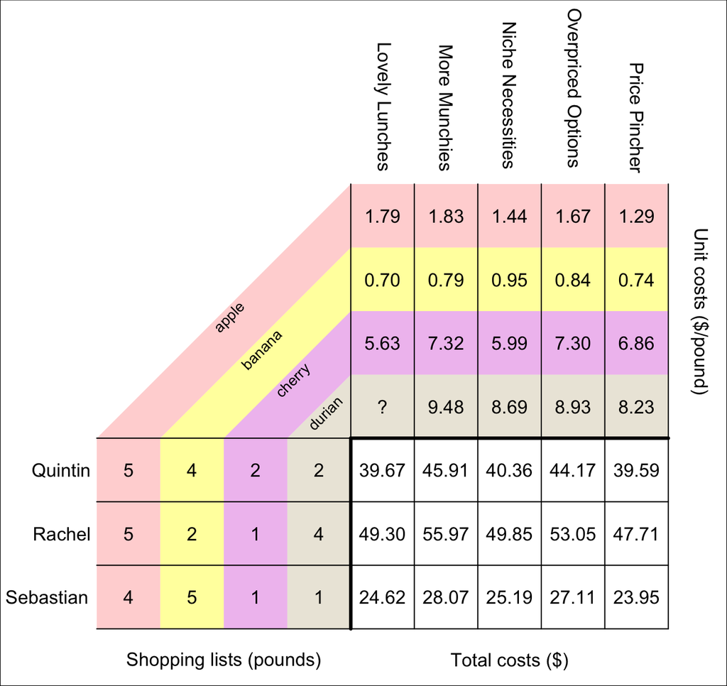

What is the unit cost of durian, in dollars per pound, at Lovely Lunches?

You can use any person's shopping trip at Lovely Lunches. Use $x$ to represent the unknown unit cost.

- If you use Quintin, solve the following equation:

$$(5\cdot 1.79)+(4\cdot 0.7)+(2\cdot
5.63)+(2\cdot x)=39.67$$

- If you use Rachel, solve the following equation:

$$(5\cdot 1.79)+(2\cdot 0.7)+(1\cdot
5.63)+(4\cdot x)=49.3$$

- If you use Sebastian, solve the following equation:

$$(4\cdot 1.79)+(5\cdot 0.7)+(1\cdot
5.63)+(1\cdot x)=24.62$$

Any equation solves to give $x=8.33$. Thus, the unit price of durian at Lovely Lunches is $8.33 per pound.

Three people are buying fruit, and there are five grocery stores. Each person has a shopping list dictating how many pounds of each fruit to buy. Each store has different unit costs of fruit.

A peculiarity of matrix multiplication requires the **columns** of the first matrix to "match" the **rows** of the second matrix. In this case, notice the various fruits correspond to columns in the first matrix (bottom-left) and rows in the second matrix (top-right). This visualization is an attempt to make this seem more natural.

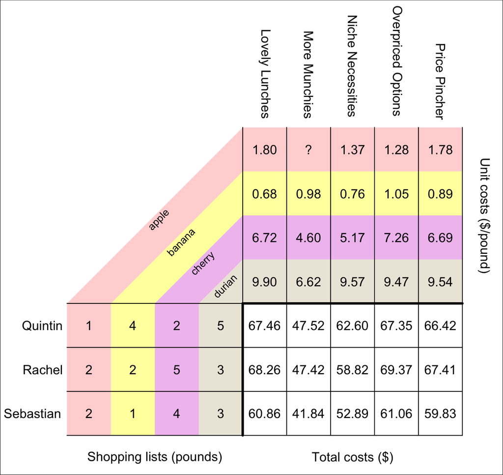

What is the unit cost of apples, in dollars per pound, at More Munchies?

You can use any person's shopping trip at More Munchies. Use $x$ to represent the unknown unit cost.

- If you use Quintin, solve the following equation:

$$(1\cdot x)+(4\cdot 0.98)+(2\cdot
4.6)+(5\cdot 6.62)=47.52$$

- If you use Rachel, solve the following equation:

$$(2\cdot x)+(2\cdot 0.98)+(5\cdot
4.6)+(3\cdot 6.62)=47.42$$

- If you use Sebastian, solve the following equation:

$$(2\cdot x)+(1\cdot 0.98)+(4\cdot
4.6)+(3\cdot 6.62)=41.84$$

Any equation solves to give $x=1.3$. Thus, the unit price of apples at More Munchies is $1.30 per pound.

Three people are buying fruit, and there are five grocery stores. Each person has a shopping list dictating how many pounds of each fruit to buy. Each store has different unit costs of fruit.

A peculiarity of matrix multiplication requires the **columns** of the first matrix to "match" the **rows** of the second matrix. In this case, notice the various fruits correspond to columns in the first matrix (bottom-left) and rows in the second matrix (top-right). This visualization is an attempt to make this seem more natural.

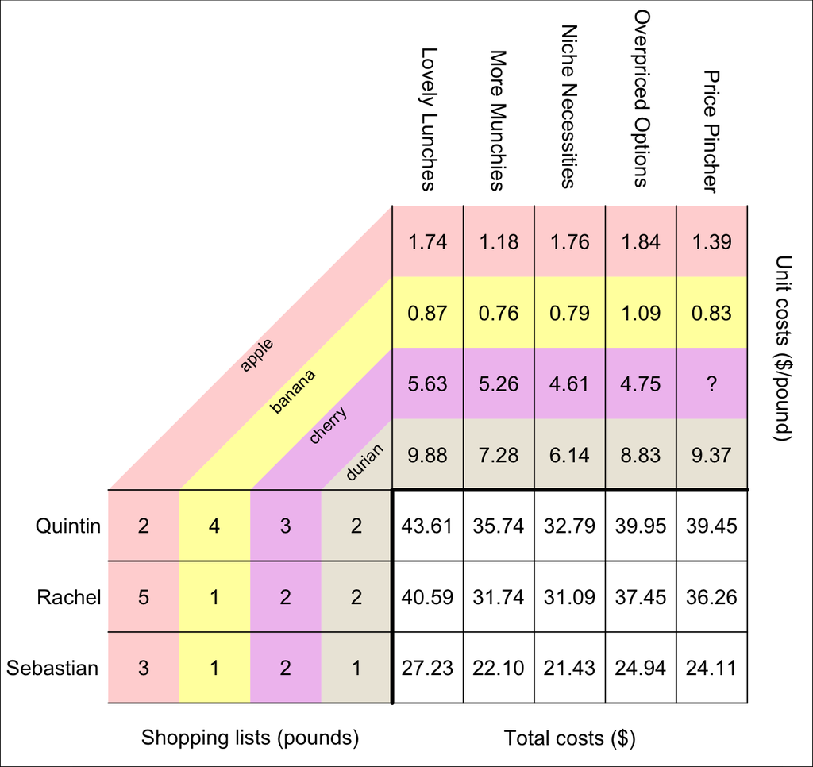

What is the unit cost of cherries, in dollars per pound, at Price Pincher?

You can use any person's shopping trip at Price Pincher. Use $x$ to represent the unknown unit cost.

- If you use Quintin, solve the following equation:

$$(2\cdot 1.39)+(4\cdot 0.83)+(3\cdot
x)+(2\cdot 9.37)=39.45$$

- If you use Rachel, solve the following equation:

$$(5\cdot 1.39)+(1\cdot 0.83)+(2\cdot
x)+(2\cdot 9.37)=36.26$$

- If you use Sebastian, solve the following equation:

$$(3\cdot 1.39)+(1\cdot 0.83)+(2\cdot
x)+(1\cdot 9.37)=24.11$$

Any equation solves to give $x=4.87$. Thus, the unit price of cherries at Price Pincher is $4.87 per pound.

Three people are buying fruit, and there are five grocery stores. Each person has a shopping list dictating how many pounds of each fruit to buy. Each store has different unit costs of fruit.

A peculiarity of matrix multiplication requires the **columns** of the first matrix to "match" the **rows** of the second matrix. In this case, notice the various fruits correspond to columns in the first matrix (bottom-left) and rows in the second matrix (top-right). This visualization is an attempt to make this seem more natural.

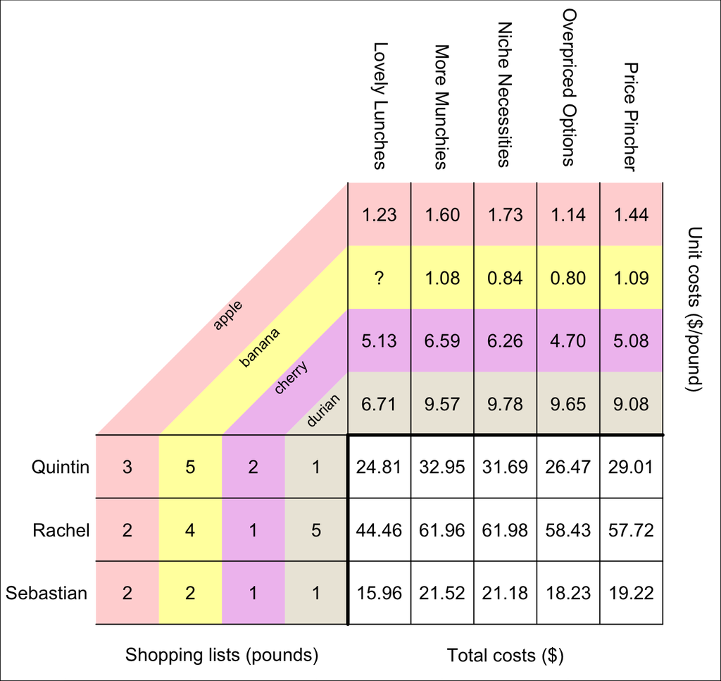

What is the unit cost of bananas, in dollars per pound, at Lovely Lunches?

You can use any person's shopping trip at Lovely Lunches. Use $x$ to represent the unknown unit cost.

- If you use Quintin, solve the following equation:

$$(3\cdot 1.23)+(5\cdot x)+(2\cdot
5.13)+(1\cdot 6.71)=24.81$$

- If you use Rachel, solve the following equation:

$$(2\cdot 1.23)+(4\cdot x)+(1\cdot
5.13)+(5\cdot 6.71)=44.46$$

- If you use Sebastian, solve the following equation:

$$(2\cdot 1.23)+(2\cdot x)+(1\cdot
5.13)+(1\cdot 6.71)=15.96$$

Any equation solves to give $x=0.83$. Thus, the unit price of bananas at Lovely Lunches is $0.83 per pound.

Three people are buying fruit, and there are five grocery stores. Each person has a shopping list dictating how many pounds of each fruit to buy. Each store has different unit costs of fruit.

A peculiarity of matrix multiplication requires the **columns** of the first matrix to "match" the **rows** of the second matrix. In this case, notice the various fruits correspond to columns in the first matrix (bottom-left) and rows in the second matrix (top-right). This visualization is an attempt to make this seem more natural.

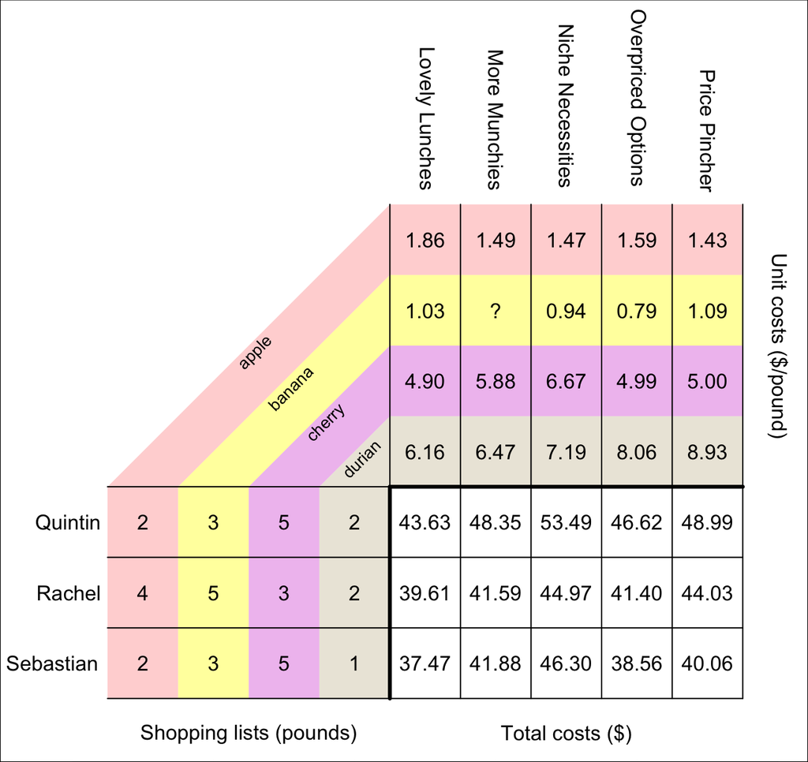

What is the unit cost of bananas, in dollars per pound, at More Munchies?

You can use any person's shopping trip at More Munchies. Use $x$ to represent the unknown unit cost.

- If you use Quintin, solve the following equation:

$$(2\cdot 1.49)+(3\cdot x)+(5\cdot
5.88)+(2\cdot 6.47)=48.35$$

- If you use Rachel, solve the following equation:

$$(4\cdot 1.49)+(5\cdot x)+(3\cdot
5.88)+(2\cdot 6.47)=41.59$$

- If you use Sebastian, solve the following equation:

$$(2\cdot 1.49)+(3\cdot x)+(5\cdot
5.88)+(1\cdot 6.47)=41.88$$

Any equation solves to give $x=1.01$. Thus, the unit price of bananas at More Munchies is $1.01 per pound.